# Start 4 All Phase 1 - Statistical Analysis Plan

v0.8 (International)

Author

Marc Henrion

Published

April 15, 2024

# TO DO LIST

- Add LR+ and LR- as performance metrics for individual tests and overall assessment of combinations. Note that since we use closed form solutions for the Bayesian model fitting, for LR+ and LR-, we will have to estimate these in the frequentist way since we cannot simply sample from the posteriors for sensitivity and specificity as these are not independent parameters… We could use MCMC (and then simply derive sets of values for LR+ and LR- from the pairs of sensitivity and specificity estimates) but computationally too demanding given the number of tests and test combinations we need to evaluate. (See https://www2.ccrb.cuhk.edu.hk/stat/confidence%20interval/Diagnostic%20Statistic.htm and https://doi.org/10.1136%2Fbmj.329.7458.168 for deriving CIs; basically treating LR+, LR- as risk ratios.)
  - LR+ = sensitivity / 1- specificity
  - LR- = 1- sensitivity / specificity
- Remove the Jan15 queries and update as per discussions from the meeting.
- Start implementing some of the diagnostic combinations as shared by Tushar (email from 31 January 2024 + later updates).
- Agree on parameter names with Amanda - tables to have all possible parameters…
- Explore use of Decision Curve Analysis (see Tom’s email from 9 April 2024 https://www.thelancet.com/journals/langlo/article/PIIS2214-109X(24)00029-9/fulltext and https://www.thelancet.com/journals/langlo/article/PIIS2214-109X(24)00061-5/fulltext).
- Add modelling for synthesizing all PHC data:
  1. Mixed binomial model for IPD meta-analysis.
  2. Mixed binomial model with covariates for interrogating associations.

# List of abbreviations

Table 1 lists all abbreviations used throughout this document.

Table 1: List of abbreviations

| Abbreviation | Explanation |
| --- | --- |
| ACF | Active case finding; the process of actively identifying people with TB. ACF aims to identify people with TB either in those who do not recognize that they have symptoms, or those who do recognize sym… |
| CAD | Computer aided diagnostic |
| CRP | C reactive protein; a blood inflammatory marker measured using point of care devices or laboratory assays, which is elevated in the presence of infections, inflammatory or neoplastic (cancer) conditio… |
| CXR | Chest x-ray |
| GA | Gastric aspirate |
| ICF | Intensified case finding at health facilities; an activity, recommended by the WHO, intended to detect possible TB cases among people attending health facilities for reasons not associated with TB (e.… |
| IDP | Internally displaced people |
| LAM | Lipoarabinomannan |
| NPA | Nasopharyngeal aspiration |
| NPV | Negative predictive value |
| PCF | Passive case finding |
| PLWH | People / person living with HIV |
| POC | Point-of-care |
| PPV | Positive predictive value |
| RDT | Rapid diagnostic test |
| SAP | Statistical Analysis Plan |
| TB | tuberculosis |

# Protocol version

# Protocol summary

Start 4 All is a large, UNITAID funded 4-year tuberculosis (TB) study programme, running in 7 countries and consisting of 2 phases:

- Phase 1 (18 months) - cross-sectional surveys to generate data on diagnostic assay performances in different countries and different populations and identifying optimal diagnostic test combinations (for screening purposes).
- Phase 2 (30 months) - a large, multi-country implementation study to evaluate the chosen optiomal combinations in the different settings.

This SAP focuses on Phase 1, with a separate SAP being written for the trial in Phase 2. There will also be a separate analysis plan for the economic evaluation of the diagnostic test combinations.

## Study design

Phase 1 consists of multiple cross-sectional surveys in 7 countries and in different general and marginalised populations within those countries.

Table 2: Summary of study populations, countries, and procedures.

| Population | Currently implemented TB screening / diagnosis approach | Local laboratory | Country | X-ray availability | Case finding approach | % with TB among those testes | Additional diagnostic tests and test combinations evaluated as part of Start 4 All |
| --- | --- | --- | --- | --- | --- | --- | --- |
| Primary health care attenders | Sympton screen; sputum smear microscopy; sputum transport for Xpert | None / basic | Bangladesh, Brazil, Cameroon, Kenya, Malawi, Nigeria, Vietnam | No | PCF / ICF | 5-15% | CAD CXR, POC CRP, CRP RDT, LAM, pooling Ultra |
| District / secondary hospital attenders | Symptom screen; sputum Xper testing (where available); 1st gen LAM for HIV positive admissions (where avilable) | Medium / some with Xpert | Bangladesh, Cameroon, Kenya, Malawi, Nigeria, Vietnam | Yes | PCF / ICF | 10-20% | CAD CXR, POC CRP, CRP RDT, LAM, pooling Ultra |
| Key / marginalised populations (informal settlements, IPDs, refugees, rural poor, pastoralists) | Symptom screen; mobile chest X-ray (predominantly human interpretation); sputum transport for smear/Xpert/culture | None | Bangladesh, Cameroon, Nigeria | Limited / mobile trucks | PCF / ICF / ACF | 0.5-10% | CAD CXR, POC CRP, CRP RDT, LAM, Pooling Ultra |
| Children | Symptom screen; Xpert testing (stool, NPA, GA, where available); X-ray (human interpretation) | Medium / some with Xpert | Cameroon, Nigeria | Yes (if in hospital) | PCF / ICF / ACF | 8-12% | CAD CXR, POC CRP, CRP RDT, LAM, pooling Ultra |

Table 2 summarises the different surveys. This study design was selected because (together with diagnostic clinical trials) surveys are considered the best design for the evaluation of diagnostics. We will evaluate the performance of HIV testing, CRP, computer assisted digital X-Rays (CAD CXR), testing multiple sputum samples by pooling them together and testing the pool with a single Xpert Ultra cartridge and urine lipoarabinomannan (LAM) as screening tests for TB. Although the performance of these tests has been described among individuals with presumptive TB, there are now updated prototypes (e.g. LAM) or software (e.g. CAD CXR) for some platforms, there is limited information on their performance among key populations (e.g. nomads/internally displaced people) and hardly any information on their performance in primary health care settings.

A composite bacteriological reference standard will be used to describe the sensitivity, specificity and positive and negative predictive value of different assays and their combinations. The composite standard will classify participants as ‘bacteriologically confirmed’, if their sputum culture or Xpert Ultra (as a single test) are positive or as ‘unlikely TB’ if they have negative culture AND negative Xpert Ultra results.

Table 3 summarises the screening assays evaluated in this study.

Table 3: Summary of screening assays evaluated in this study.

| Assay type | Assay |
| --- | --- |
| HIV testing | HIV |
| Point-of-care C-Reactive Protein (quantitative) | POC CRP |
| Point-of-care C-Reactive Protein (semi-quantitative) | CRP RDT |
| Urine Lateral Flow Test | FujiLAM |
| Molecular diagnostic | Pooled Xpert |
| Computer-aided detection from digital chest X-ray | Digital chest X-ray + Qure.ai |

**Jan15 discussion:** Should pooled Xpert be a screening or a diagnostic / confirmatory test?

**Jan15 discussion:** Do we get individual results from the pooled Xpert or just whether at least one of the pooled samples was positive? If the latter, then a bit difficult to derived sensitivity, specificity, PPV, NPV etc.

## Study Endpoints

### Primary endpoint

Generation of robust estimates of the diagnostic accuracy and performance of TB diagnostic tests and test combinations in primary healthcare settings and key and vulnerable populations.

### Secondary study endpoints

- Estimates of the predicted performance of TB diagnostic test combinations and how they perform in specific populations.
- Selection of the optimal TB diagnostic test combinations for implementation and scale-up in primary healthcare settings and key and vulnerable populations in terms of their cost-efficiency, feasibility, and modelled accuracy.

## Sample size

The sample sizes were chosen to comply with the sample size criterion required for WHO guideline development and to achieve an acceptable level of precision for the estimates of the performance of the diagnostic tests. The sample sizes are also suitable for estimating costs and cost-efficiency of the TB diagnostic combinations.

$$n_{unadj}=p\cdot(1-p)\cdot\left(\frac{z_{\alpha/2}}{E}\right)^2$$
where $p$ = target proportion (sensitivity in your case; $p=0.9$), E = target precision (or margin-of-error) and $z_{\alpha/2}$ is the (two-sided) critical value from the normal distribution for significance level $\alpha$ (in our case $\alpha=0.05$ and $z_{alpha/2}=1.96$).

```r
sampSize_OnePropCI<-function(p_hat,E=NULL,n=NULL,alpha=0.05,method="WaldNormalApprox"){
  # p_hat = expected proportion
  # E = desired error of margin (half width of the confidence interval); if specified then n gets computed
  # n = fixed sample size; if specified then E gets computed
  # alpha = 1 - confidence level
  # method = one of "WaldNormalApprox" or "WilsonScoreApprox"
  # NOTE: exactly one of n, E needs to be specified -- they cannot both be set to NULL or both be specified

  z<-qnorm(1-alpha/2)

  if(is.null(n) & !is.null(E)){
    if(method=="WaldNormalApprox"){
      n<-p_hat*(1-p_hat)*(z/E)^2
    }else if(method=="WilsonScoreApprox"){
      a<-1
      b<-(2-p_hat*(1-p_hat)/E^2)*z^2
      c<-(4*E^2-1)*(z^4)/(4*E^2)
      n<-(-b + sqrt(b^2-4*a*c))/(2*a)
    }else{stop("The method parameter needs to be one of WaldNormalApprox or WilsonScoreApprox")}

    return(n)
  }else if (is.null(E) & !is.null(n)){
    if(method=="WilsonScoreApprox"){warning("Argument method is set to WilsonScoreApprox but this will be ignored and WaldNormalApprox be used instead.")}
    E<-sqrt((p_hat*(1-p_hat)*z^2)/n)

    return(E)
  }else{
    stop("E and n cannot both be NULL or both be specified - you need to specify one of these two and leave the other unspecified / NULL.")
  }

}

dfSS<-data.frame(
  tbPrevalence=c(1:5,8:10,12,15,20,27)/100,
  prec5=NA,
  prec6=NA,
  prec7=NA,
  prec8=NA,
  prec10=NA,
  prec15=NA
) %>%
  mutate(
    prec5=paste(sep=" / ",ceiling(sampSize_OnePropCI(p_hat=0.9,E=0.05)),ceiling(c(ceiling(sampSize_OnePropCI(p_hat=0.9,E=0.05))/tbPrevalence))),
    prec6=paste(sep=" / ",ceiling(sampSize_OnePropCI(p_hat=0.9,E=0.06)),ceiling(c(ceiling(sampSize_OnePropCI(p_hat=0.9,E=0.06))/tbPrevalence))),
    prec7=paste(sep=" / ",ceiling(sampSize_OnePropCI(p_hat=0.9,E=0.07)),ceiling(c(ceiling(sampSize_OnePropCI(p_hat=0.9,E=0.07))/tbPrevalence))),
    prec8=paste(sep=" / ",ceiling(sampSize_OnePropCI(p_hat=0.9,E=0.08)),ceiling(c(ceiling(sampSize_OnePropCI(p_hat=0.9,E=0.08))/tbPrevalence))),
    prec10=paste(sep=" / ",ceiling(sampSize_OnePropCI(p_hat=0.9,E=0.1)),ceiling(c(ceiling(sampSize_OnePropCI(p_hat=0.9,E=0.1))/tbPrevalence))),
    prec15=paste(sep=" / ",ceiling(sampSize_OnePropCI(p_hat=0.9,E=0.15)),ceiling(c(ceiling(sampSize_OnePropCI(p_hat=0.9,E=0.15))/tbPrevalence)))
  ) %>%
  mutate(tbPrevalence=paste(sep="",100*tbPrevalence,"%"))

dfSS %>%
  kable(row.names=FALSE,col.names=c("","5%","6%","7%","8%","10%","15%")) %>%
  kable_styling(full_width=FALSE) %>%
  add_header_above(c("TB prevalence"=1,"Precision"=6)) %>%
  add_header_above(c(" "=1,"Expected number microbiologically confirmed / number required in sample"=6))
```

Table 4: Sample size calculation for adults.

| TB prevalence | Expected number microbiologically confirmed / number required in sample Precision 5% | Expected number microbiologically confirmed / number required in sample Precision 6% | Expected number microbiologically confirmed / number required in sample Precision 7% | Expected number microbiologically confirmed / number required in sample Precision 8% | Expected number microbiologically confirmed / number required in sample Precision 10% | Expected number microbiologically confirmed / number required in sample Precision 15% |
| --- | --- | --- | --- | --- | --- | --- |
| 1% | 139 / 13900 | 97 / 9700 | 71 / 7100 | 55 / 5500 | 35 / 3500 | 16 / 1600 |
| 2% | 139 / 6950 | 97 / 4850 | 71 / 3550 | 55 / 2750 | 35 / 1750 | 16 / 800 |
| 3% | 139 / 4634 | 97 / 3234 | 71 / 2367 | 55 / 1834 | 35 / 1167 | 16 / 534 |
| 4% | 139 / 3475 | 97 / 2425 | 71 / 1775 | 55 / 1375 | 35 / 875 | 16 / 400 |
| 5% | 139 / 2780 | 97 / 1940 | 71 / 1420 | 55 / 1100 | 35 / 700 | 16 / 320 |
| 8% | 139 / 1738 | 97 / 1213 | 71 / 888 | 55 / 688 | 35 / 438 | 16 / 200 |
| 9% | 139 / 1545 | 97 / 1078 | 71 / 789 | 55 / 612 | 35 / 389 | 16 / 178 |
| 10% | 139 / 1390 | 97 / 970 | 71 / 710 | 55 / 550 | 35 / 350 | 16 / 160 |
| 12% | 139 / 1159 | 97 / 809 | 71 / 592 | 55 / 459 | 35 / 292 | 16 / 134 |
| 15% | 139 / 927 | 97 / 647 | 71 / 474 | 55 / 367 | 35 / 234 | 16 / 107 |
| 20% | 139 / 695 | 97 / 485 | 71 / 355 | 55 / 275 | 35 / 175 | 16 / 80 |
| 27% | 139 / 515 | 97 / 360 | 71 / 263 | 55 / 204 | 35 / 130 | 16 / 60 |

The resulting number $n_{unadj}$ needs to be adjusted for the TB prevalence, $p_{TB}$:

$$n_{adj}=\frac{n_{unadj}}{p_{TB}}$$

We further need to take into account different levels of expected attrition (due to loss-to-follow-up; unusable data or other causes):

$$n_{final}=\frac{n_{adj}}{1-p_{attr}}$$

where $p_{attr}$ is the expected proportion of attrition.

The studies will be analyzed individually by countries, and then as a single multi-country evaluation. The latter aims to achieve the requirements of data for WHO guidance, which requests at least 250 individuals with bacteriologically confirmed TB.

As shown in Table 5, the total sample size to be enrolled varies with the average TB prevalence, target precision and expected loss-to-follow-up (individuals not completing a diagnostic process) in the individual countries and sites. However, with the assumptions shown in Table 5, and assuming an overall proportion of 50% people living with HIV (PLWH) adult participants, we estimate a sample size of 7,200 PLWH and 7,200 HIV-negative persons will include at least 548 PLWH and 548 HIV-negative persons (total 1,096) with a microbiologically confirmed diagnosis of TB.

It is expected that countries with a high burden of HIV-associated TB (Brazil, Cameroon, Kenya, Malawi, Nigeria) will recruit an even higher ratio of PLWH to HIV-negative participants. If the recruitment of PLWH is lower than expected, countries with high burden of HIV-associated TB will enrich recruitment towards this population by recruiting in HIV care and treatment clinics and outpatient centres.

The number of adult males is expected to be higher than the number of females, as more males are affected by TB and a higher proportion of males than females attend primary and secondary clinics. The proportion of participants with TB that is obtained at the end of Phase 1 may vary from the expected proportion of participants with TB due to the inclusion of ICF and ACF in the study in settings in which they are not normally applied (i.e. ICF being conducted in PHC clinics). Additionally, some populations maybe feel more encouraged or discouraged to participate in the study, which may be reflected in the proportion of TB cases for a particular setting and the reasons behind this may be elucidated during the Realist Evaluation.

```r
dfSSCountry<-data.frame(
  country=c(rep("Cameroon",4),rep("Nigeria",4),rep("Kenya",2),rep("Bangladesh",3),rep("Brazil",2),rep("Vietnam",3),rep("Malawi",1),"TOTAL"),
  setting=c("PHC clinics","District hospital","Informal settlement / rural poor ACF","Children","PHC clinics","District hospital","Nomads","IDP / refugees","PHC clinics","District hospital","PHC clinics","District hospital","Informal settlements / rural poor ACF","PHC clinics Aracaju","PHC clinics Maceio","PHC clinics","Informal settlements ACF","Children","PHC clinics",NA),
  expectedTbProp=c(paste(sep="",c(9,8,5,4,10,20,8,12,9,20,5,3,5,15,27,2,1,0,6),"%"),NA),
  targetPrecision=c(paste(sep="",c(7,7,10,15,6.5,5.5,7,6,8,5.5,9,12,9,7,5.5,15,17,NA,8),"%"),NA),
  expectedAttrition=c(paste(sep="",c(20,12,15,20,18,18,12,20,12,18,14,16,14,5,10,20,20,NA,20),"%"),NA),
  sampleSize=c(c(1000,1000,800,500,1000,700,1000,1000,700,700,1000,1000,1000,500,500,1000,1500,500,1200),NA),
  expectedAdultTB=c(72,70,34,NA,82,114,70,96,55,114,43,26,43,71,121,16,12,NA,57,1096),
  adults=c(2800,rep(NA,3),3700,rep(NA,3),1400,NA,3000,rep(NA,2),1000,NA,2500,rep(NA,2),1200,14400),
  children=c(500,rep(NA,3),rep(NA,4),rep(NA,2),rep(NA,3),rep(NA,2),500,rep(NA,2),NA,1000)
)

dfSSCountry[dfSSCountry=="NA%"]<-NA

dfSSCountry %>%
  dplyr::select(!country) %>%
  kable(row.names=FALSE,col.names=c("Country & setting","Expected proportion with TB","Target precision","Expected attrition","Sample size","Expected adults with TB","Adults","Children"),format.args = list(big.mark = ",")) %>%
  kable_styling(full_width = FALSE) %>%
  pack_rows("Cameroon",1,4) %>%
  pack_rows("Nigeria",5,8) %>%
  pack_rows("Kenya",9,10) %>%
  pack_rows("Bangladesh",11,13) %>%
  pack_rows("Brazil",14,15) %>%
  pack_rows("Vietnam",16,18) %>%
  pack_rows("Malawi",19,19) %>%
  pack_rows("TOTAL",20,20)
```

Table 5: Sample size for each survey.

| Country & setting | Expected proportion with TB | Target precision | Expected attrition | Sample size | Expected adults with TB | Adults | Children |
| --- | --- | --- | --- | --- | --- | --- | --- |
| **Cameroon** |  |  |  |  |  |  |  |
| PHC clinics | 9% | 7% | 20% | 1,000 | 72 | 2,800 | 500 |
| District hospital | 8% | 7% | 12% | 1,000 | 70 | . | . |
| Informal settlement / rural poor ACF | 5% | 10% | 15% | 800 | 34 | . | . |
| Children | 4% | 15% | 20% | 500 | . | . | . |
| **Nigeria** |  |  |  |  |  |  |  |
| PHC clinics | 10% | 6.5% | 18% | 1,000 | 82 | 3,700 | . |
| District hospital | 20% | 5.5% | 18% | 700 | 114 | . | . |
| Nomads | 8% | 7% | 12% | 1,000 | 70 | . | . |
| IDP / refugees | 12% | 6% | 20% | 1,000 | 96 | . | . |
| **Kenya** |  |  |  |  |  |  |  |
| PHC clinics | 9% | 8% | 12% | 700 | 55 | 1,400 | . |
| District hospital | 20% | 5.5% | 18% | 700 | 114 | . | . |
| **Bangladesh** |  |  |  |  |  |  |  |
| PHC clinics | 5% | 9% | 14% | 1,000 | 43 | 3,000 | . |
| District hospital | 3% | 12% | 16% | 1,000 | 26 | . | . |
| Informal settlements / rural poor ACF | 5% | 9% | 14% | 1,000 | 43 | . | . |
| **Brazil** |  |  |  |  |  |  |  |
| PHC clinics Aracaju | 15% | 7% | 5% | 500 | 71 | 1,000 | . |
| PHC clinics Maceio | 27% | 5.5% | 10% | 500 | 121 | . | . |
| **Vietnam** |  |  |  |  |  |  |  |
| PHC clinics | 2% | 15% | 20% | 1,000 | 16 | 2,500 | 500 |
| Informal settlements ACF | 1% | 17% | 20% | 1,500 | 12 | . | . |
| Children | 0% | . | . | 500 | . | . | . |
| **Malawi** |  |  |  |  |  |  |  |
| PHC clinics | 6% | 8% | 20% | 1,200 | 57 | 1,200 | . |
| **TOTAL** |  |  |  |  |  |  |  |
| . | . | . | . | . | 1,096 | 14,400 | 1,000 |

## Objectives

### Primary objective

To evaluate the performance of selected TB screening tests and combinations of such tests.

### Secondary objectives

- To identify test combinations that increase the proportion of people diagnosed with microbiologically confirmed TB.
- To demonstrate that combinations of current and newer TB tests can facilitate using these tests in locations where they are not currently available.

# Data simulation

In order to demonstrate the planned analyses and show computer code, we will simulate data like the one expected to be generated by the study.

```r
set.seed(123)

sensSpecMatHiv<-data.frame(
  sens=rnorm(n=7,mean=0.8,sd=0.02),
  spec=rnorm(n=7,mean=0.8,sd=0.01)
)
rownames(sensSpecMatHiv)<-c("Cameroon","Nigeria","Kenya","Bangladesh","Brazil","Vietnam","Malawi")

sensSpecMatCrpRdt<-data.frame(
  sens=rnorm(n=7,mean=0.85,sd=0.025),
  spec=rnorm(n=7,mean=0.92,sd=0.01)
)
rownames(sensSpecMatCrpRdt)<-c("Cameroon","Nigeria","Kenya","Bangladesh","Brazil","Vietnam","Malawi")

sensSpecMatCrpPoc<-data.frame(
  sens=rnorm(n=7,mean=0.9,sd=0.02),
  spec=rnorm(n=7,mean=0.95,sd=0.01)
)
rownames(sensSpecMatCrpPoc)<-c("Cameroon","Nigeria","Kenya","Bangladesh","Brazil","Vietnam","Malawi")

sensSpecMatCrpRdt<-data.frame(
  sens=rnorm(n=7,mean=0.85,sd=0.025),
  spec=rnorm(n=7,mean=0.92,sd=0.01)
)
rownames(sensSpecMatCrpRdt)<-c("Cameroon","Nigeria","Kenya","Bangladesh","Brazil","Vietnam","Malawi")

sensSpecMatLamFuji<-data.frame(
  sens=rnorm(n=7,mean=0.82,sd=0.02),
  spec=rnorm(n=7,mean=0.9,sd=0.01)
)
rownames(sensSpecMatLamFuji)<-c("Cameroon","Nigeria","Kenya","Bangladesh","Brazil","Vietnam","Malawi")

# sensSpecMatLamBiopromic<-data.frame(
#   sens=rnorm(n=7,mean=0.83,sd=0.02),
#   spec=rnorm(n=7,mean=0.89,sd=0.01)
# )
# rownames(sensSpecMatLamBiopromic)<-c("Cameroon","Nigeria","Kenya","Bangladesh","Brazil","Vietnam","Malawi")

sensSpecMatXpertPooled<-data.frame(
  sens=rnorm(n=7,mean=0.92,sd=0.01),
  spec=rnorm(n=7,mean=0.97,sd=0.01)
)
rownames(sensSpecMatXpertPooled)<-c("Cameroon","Nigeria","Kenya","Bangladesh","Brazil","Vietnam","Malawi")

sensSpecMatCad<-data.frame(
  sens=rnorm(n=7,mean=0.88,sd=0.025),
  spec=rnorm(n=7,mean=0.88,sd=0.02)
)
rownames(sensSpecMatCad)<-c("Cameroon","Nigeria","Kenya","Bangladesh","Brazil","Vietnam","Malawi")

# sensSpecMatCadMinxray<-data.frame(
#   sens=rnorm(n=7,mean=0.87,sd=0.025),
#   spec=rnorm(n=7,mean=0.89,sd=0.02)
# )
# rownames(sensSpecMatCadMinxray)<-c("Cameroon","Nigeria","Kenya","Bangladesh","Brazil","Vietnam","Malawi")

sensSpecMatXpert<-data.frame(
  sens=rnorm(n=7,mean=0.98,sd=0.005),
  spec=rnorm(n=7,mean=0.99,sd=0.005)
)
sensSpecMatXpert$sens[sensSpecMatXpert$sens>=0.99999]<-0.99999
sensSpecMatXpert$spec[sensSpecMatXpert$spec>=0.99999]<-0.99999
rownames(sensSpecMatXpert)<-c("Cameroon","Nigeria","Kenya","Bangladesh","Brazil","Vietnam","Malawi")


dfSim<-data.frame(
  country=c(rep("Cameroon",3300),rep("Nigeria",3400),rep("Kenya",1400),rep("Bangladesh",3000),rep("Brazil",1000),rep("Vietnam",3000),rep("Malawi",1200)),
  region=c(rep("",3300+3400+1400+3000),rep("Aracaju",500),rep("Maceio",500),rep("",3000+1200)),
  setting=c(rep("PHC",1000),rep("District",1000),rep("Informal settlements ACF",800),rep("Children",500),rep("PHC",700),rep("District",700),rep("Nomads",1000),rep("IDP / refugees",1000),rep("PHC",700),rep("District",700),rep("PHC",1000),rep("District",1000),rep("Informal settlements ACF",1000),rep("PHC",1000),rep("PHC",1000),rep("Informal settlements ACF",1500),rep("Children",500),rep("PHC",1200)),
  reference=c(rbinom(n=1000,size=1,prob=0.09),rbinom(n=1000,size=1,prob=0.08),rbinom(n=800,size=1,prob=0.05),rbinom(n=500,size=1,prob=0.04),rbinom(n=700,size=1,prob=0.20),rbinom(n=700,size=1,prob=0.20),rbinom(n=1000,size=1,prob=0.08),rbinom(n=1000,size=1,prob=0.12),rbinom(n=700,size=1,prob=0.09),rbinom(n=700,size=1,prob=0.20),rbinom(n=1000,size=1,prob=0.05),rbinom(n=1000,size=1,prob=0.03),rbinom(n=1000,size=1,prob=0.05),rbinom(n=500,size=1,prob=0.15),rbinom(n=500,size=1,prob=0.27),rbinom(n=1000,size=1,prob=0.02),rbinom(n=1500,size=1,prob=0.01),rbinom(n=500,size=1,prob=0.001),rbinom(n=1200,size=1,prob=0.08))
  ) %>%
  dplyr::mutate(
    hiv=case_when(reference==0~rbinom(n=n(),size=1,prob=1-sensSpecMatHiv[country,"spec"]),reference==1~rbinom(n=n(),size=1,prob=sensSpecMatHiv[country,"sens"])),
    crpPoc=case_when(reference==0~rbinom(n=n(),size=1,prob=1-sensSpecMatCrpPoc[country,"spec"]),reference==1~rbinom(n=n(),size=1,prob=sensSpecMatCrpPoc[country,"sens"])),
    crpRdt=case_when(reference==0~rbinom(n=n(),size=1,prob=1-sensSpecMatCrpRdt[country,"spec"]),reference==1~rbinom(n=n(),size=1,prob=sensSpecMatCrpRdt[country,"sens"])),
    lamFuji=case_when(reference==0~rbinom(n=n(),size=1,prob=1-sensSpecMatLamFuji[country,"spec"]),reference==1~rbinom(n=n(),size=1,prob=sensSpecMatLamFuji[country,"sens"])),
    # lamBiopromic=case_when(reference==0~rbinom(n=n(),size=1,prob=1-sensSpecMatLamBiopromic[country,"spec"]),reference==1~rbinom(n=n(),size=1,prob=sensSpecMatLamBiopromic[country,"sens"])),
    xpertPooled=case_when(reference==0~rbinom(n=n(),size=1,prob=1-sensSpecMatXpertPooled[country,"spec"]),reference==1~rbinom(n=n(),size=1,prob=sensSpecMatXpertPooled[country,"sens"])),
    cad=case_when(reference==0~rbinom(n=n(),size=1,prob=1-sensSpecMatCad[country,"spec"]),reference==1~rbinom(n=n(),size=1,prob=sensSpecMatCad[country,"sens"])),
    #cadMinxray=case_when(reference==0~rbinom(n=n(),size=1,prob=1-sensSpecMatCadMinxray[country,"spec"]),reference==1~rbinom(n=n(),size=1,prob=sensSpecMatCadMinxray[country,"sens"])),
    xpert=case_when(reference==0~rbinom(n=n(),size=1,prob=1-sensSpecMatXpert[country,"spec"]),reference==1~rbinom(n=n(),size=1,prob=sensSpecMatXpert[country,"sens"]))
)

dfSim[sample(size=10,replace=F,x=1:nrow(dfSim)),] %>%
  kable(row.names=FALSE) %>%
  kable_styling(full_width=FALSE)
```

Table 6: 10 random rows from the simulated data.

| country | region | setting | reference | hiv | crpPoc | crpRdt | lamFuji | xpertPooled | cad | xpert |
| --- | --- | --- | --- | --- | --- | --- | --- | --- | --- | --- |
| Cameroon |  | Children | 0 | 1 | 0 | 0 | 0 | 0 | 1 | 0 |
| Kenya |  | District | 0 | 1 | 0 | 0 | 0 | 0 | 0 | 0 |
| Kenya |  | District | 0 | 0 | 0 | 0 | 0 | 0 | 0 | 0 |
| Bangladesh |  | Informal settlements ACF | 0 | 1 | 0 | 0 | 0 | 1 | 0 | 0 |
| Kenya |  | PHC | 0 | 0 | 0 | 0 | 0 | 0 | 0 | 0 |
| Nigeria |  | District | 1 | 1 | 1 | 1 | 1 | 1 | 1 | 1 |
| Brazil | Maceio | PHC | 0 | 0 | 0 | 0 | 0 | 0 | 0 | 0 |
| Bangladesh |  | PHC | 0 | 1 | 0 | 0 | 0 | 0 | 0 | 0 |
| Cameroon |  | Informal settlements ACF | 0 | 1 | 0 | 0 | 0 | 0 | 0 | 0 |
| Vietnam |  | Informal settlements ACF | 0 | 1 | 0 | 0 | 0 | 0 | 0 | 0 |

Table 6 shows 10 random rows from the data frame containing all 16300 simulated observations.

# Statistical Analysis Plan

The R code to generate the results is embedded in this document. By default it is hidden, but can be displayed by clicking on the `Code` boxes on the right hand side.

## General considerations

The reporting of this study will be prepared in accordance with the STROBE guidelines (von Elm et al. 2007).

All continuous data variables will be summarized using the following descriptive statistics:

- N (size of relevant analysis population)
- n (size of analysis population without missing values)
- arithmetic mean (or geometric mean if more appropriate)
- standard deviation (SD)
- median
- 25th percentile value (P25), 75th percentile value (P75) and interquartile range (IQR)
- minimum and maximum (where relevant)

The proportion / percentage of observed levels will be reported for all binary and categorical measures. When appropriate, corresponding exact 95% confidence intervals (CIs) for proportions will be included.

For statistical test, a significance level of 5% will be used. All p-values will be reported to 3 decimal digits.

### Reporting conventions

P-values $\geq 0.001$ and $\leq 0.999$ will be reported to 3 decimal places; p-values less than 0.001 will be reported as “< 0.001”. The mean, standard deviation, median, IQR and other statistics will be reported to one decimal place greater than the original data. Minimum and maximum values will use the same number of decimal places as the original data. Proportions will be presented as two decimal places; values greater than zero but $<0.01$ will be presented as “< 0.01”. Percentages will be reported to 2 decimal places; values greater than zero but $<0.01\%$ will be presented as “< 0.01%”; values greater than $99.99\%$ but less than $100\%$ will be reported as “> 99.99%”. Estimated parameters, not on the same scale as raw observations (e.g. regression coefficients) will be reported to 3 significant figures.

### Missing data

As all samples for the test diagnostics get taken at the only study visit, we expect only marginal missing data. Any missing data that does arise we expect to be due to technical reasons unrelated to the outcome of interest. For this reason, the main analysis will be a complete-case analysis. For sensitivity analyses, we will, for each of the main objectives, conduct i) worst-case and ii) best-case scenario imputations and analyse the data with these imputations.

While we do not anticipate much missing data, should the missing data, for whatever reason, be more substantial than expected (say exceed 5% of the total data), we will use multiple imputation for the analysis. Specifically we will use fully conditional specification (FCS) as implemented in Multiple Imputation using Chained Equations (MICE, van Buuren and Groothuis-Oudshoorn (2011)) and the `mice` package in R, with m=10 imputations at least.

### Technical details

The R environment for statistical computing (v4.2.2 or later) will be used for all analyses.

All analysis code will be made publicly available under an MIT or GNU GPL v3.0 license on GitHub.

## Primary objective analyses

For the primary objective we will estimate performance metrics for individual screening tests as well as combinations (“screening algorithms”) of tests. Specifically, we will estimate:

- Sensitivity (Se)
- Specificity (Sp)
- Positive predictive value (PPV)
- Negative predictive value (NPV)
- Likelihood ratio for a positive test result (LR+) = Se/(1-Sp)
- Likelihood ratio for a negative test result (LR-) = (1-Se)/Sp

In addition to these we will also compute the proportion of positive tests as this will be needed for the subsequent health economic analysis.

- Proportion of positive test results.

### Estimation

We will estimate all of the probability parameters using Bayesian statistics. In Bayesian estimation, rather than calculating point estimates for each parameter of interest, the parameters are considered to be random variables and one estimates a distribution for each parameter. All of the parameters of interest in Phase 1 of Start 4 All (TB prevalence, sensitivities, specificities, PPVs, NPVs and proportion of positive tests) are probability parameters. The natural parametric distribution for such parameters is the beta distribution as it has support over the interval $[0,1]$.

Recall that a random variable $X$ follows a beta distribution with parameters $a,b$, $X\sim\beta(a,b)$, if

$$p(x)=\begin{cases}
\frac{x^{a-1}(1-x)^{b-1}}{B(a,b)} &\mbox{ if }x\in[0,1] \\
0 &\mbox{ otherwise}
\end{cases}$$

where $B(a,b)=\frac{\Gamma(a)\Gamma(b)}{\Gamma(a+b)}$.

The mean of this distribution is given by $E(X)=\frac{a}{a+b}$ and the variance is $Var(X)=\frac{a\cdot b}{(a+b)^2(a+b+1)}$. The mode is given by $\frac{a-1}{a+b-2}$, but this is only defined if $a,b>1$.

In Bayesian estimation, we estimate the posterior probability density of a given parameter; *posterior* because it is the best-fit distribution after we have observed data. The posterior distribution summarises our beliefs about the likely values for the parameter of interest and it is an update of our beliefs about the parameter before we had observed data – the prior distribution. The data are generated by a stochastic process and we can compute the likelihood of the data under a distribution for this process. To summarise:

$$\mbox{posterior} = \mbox{prior} \times \mbox{likelihood}$$
In our case, since all our parameters of interest (except LR+ and LR- which can be derived from the others) are probability parameters, the prior distribution we will use a beta prior distribution, $p\sim\beta(a,b)$, where $p$ is the probability parameter of interest, and a binomial likelihood $X\sim Bin(n,p)$, where $X$ is the number of positive results, $n$ the total number of observations and $p$ the same probability parameter as in the prior. One can show that the posterior will also be a beta distribution (since the beta is the conjugate prior for a binomial likelihood) with a closed form solution: $p|X=k\sim\beta(k+a,n-k+b)$. The closed-form solution means this is computationally extremely fast to compute. For prior, a weakly informative prior will be used, specifically the Kerman prior $\beta(1/3,1/3)$ (Kerman 2011).

Specifically in our case, for a probability parameter of interest $p$, if we observe $X=k$ positive results out of $n$ total observations, then the posterior distribution will be a beta distribution with parameters $a=k+\frac{1}{3}$ and $b=n-k+\frac{1}{3}$:

$$p|n,X=k\sim\beta(k+a,n-k+b)$$

The distributional parameters $a,b$ for the posterior will be of direct interest for the health economic modelling and it are these values that will be the input to that analysis. For reporting performances of the different tests and combination of tests, we need, however, point estimates. We can easily derive these, together with 95% confidence intervals, from the estimated posterior beta distributions. As there is more than one way to do this, we need to specify how we will do this. We will:

- Derive point estimates as the posterior mode, also called maximum a posteriori estimate. This is the value that maximises the posterior distribution (i.e. the most likely value under the posterior). In our case this will be $\hat{p}=\frac{k-2/3}{n-4/3}$. This equation is not always valid (but almost always will be; we just need $0<k<n$); we will report a mode of 0 if $k=0$ and a mode of 1 if $k=n$.
- Derive Bayesian confidence intervals (also called credible intervals) as the 95% highest posterior density intervals; i.e. the interval containing 95% of the posterior density such that no value inside the interval has lower density than any value outside the interval. (To note that highest density intervals are not always intervals if the distribution is multi-modal for example; for our case of a beta-binomial Bayesian model, the HDI will always be an interval as long as we have at least 1 data point – at least one of the parameters of the posterior beta distribution is $\geq1$ in this case.)

```r
propEstBetaBayes<-function(n,k,prior_a=1/3,prior_b=1/3){
  ab<-c(k+prior_a,n-k+prior_b)
  if(n>0 & (k+prior_a)>=1 & (n-k+prior_b)>=1){
    map<-(k+prior_a-1)/(n+prior_a+prior_b-2)
    ci<-HDInterval::hdi(rbeta(1e6,shape1=ab[1],shape2=ab[2]))
  }else if(n>0 & (k+prior_a)<1 & (n-k+prior_b)>=1){
    map<-0
    ci<-HDInterval::hdi(rbeta(1e6,shape1=ab[1],shape2=ab[2]))
  }else if (n>0 & (k+prior_a)>=1 & (n-k+prior_b)<1){
    map<-1
    ci<-HDInterval::hdi(rbeta(1e6,shape1=ab[1],shape2=ab[2]))
  }else if(k==0 & n==0){
    map<-NA
    ci<-NA
  }

  return(list(parameters=ab,estimate=map,ci=ci))
}

analysisFunBayesBetaPars<-function(dat,c,r,s){
  dat<-dat %>% dplyr::filter(country==c & region==r & setting==s)

  prevalenceTB=propEstBetaBayes(k=sum(dat$reference),n=nrow(dat))$parameters
  posPropHiv=propEstBetaBayes(k=sum(dat$hiv==1),n=nrow(dat))$parameters
  if(sum(dat$reference==1)>0){sensHiv=propEstBetaBayes(k=sum(dat$reference==1 & dat$hiv==1),n=sum(dat$reference==1))$parameters}else{sensHiv=rep(NA,2)}
  if(sum(dat$reference==1)>0){specHiv=propEstBetaBayes(k=sum(dat$reference==0 & dat$hiv==0),n=sum(dat$reference==0))$parameters}else{specHiv=rep(NA,2)}
  if(sum(dat$hiv==1)>0){ppvHiv=propEstBetaBayes(k=sum(dat$reference==1 & dat$hiv==1),n=sum(dat$hiv==1))$parameters}else{ppvHiv=rep(NA,2)}
  if(sum(dat$hiv==0)>0){npvHiv=propEstBetaBayes(k=sum(dat$reference==0 & dat$hiv==0),n=sum(dat$hiv==0))$parameters}else{npvHiv=rep(NA,2)}
  posPropCrpPoc=propEstBetaBayes(k=sum(dat$crpPoc==1),n=nrow(dat))
  if(sum(dat$reference==1)>0){sensCrpPoc=propEstBetaBayes(k=sum(dat$reference==1 & dat$crpPoc==1),n=sum(dat$reference==1))$parameters}else{sensCrpPoc=rep(NA,2)}
  if(sum(dat$reference==1)>0){specCrpPoc=propEstBetaBayes(k=sum(dat$reference==0 & dat$crpPoc==0),n=sum(dat$reference==0))$parameters}else{specCrpPoc=rep(NA,2)}
  if(sum(dat$crpPoc==1)>0){ppvCrpPoc=propEstBetaBayes(k=sum(dat$reference==1 & dat$crpPoc==1),n=sum(dat$crpPoc==1))$parameters}else{ppvCrpPoc=rep(NA,2)}
  if(sum(dat$crpPoc==0)>0){npvCrpPoc=propEstBetaBayes(k=sum(dat$reference==0 & dat$crpPoc==0),n=sum(dat$crpPoc==0))$parameters}else{npvCrpPoc=rep(NA,2)}
  posPropCrpRdt=propEstBetaBayes(k=sum(dat$crpRdt==1),n=nrow(dat))
  if(sum(dat$reference==1)>0){sensCrpRdt=propEstBetaBayes(k=sum(dat$reference==1 & dat$crpRdt==1),n=sum(dat$reference==1))$parameters}else{sensCrpRdt=rep(NA,2)}
  if(sum(dat$reference==1)>0){specCrpRdt=propEstBetaBayes(k=sum(dat$reference==0 & dat$crpRdt==0),n=sum(dat$reference==0))$parameters}else{specCrpRdt=rep(NA,2)}
  if(sum(dat$crpRdt==1)>0){ppvCrpRdt=propEstBetaBayes(k=sum(dat$reference==1 & dat$crpRdt==1),n=sum(dat$crpRdt==1))$parameters}else{ppvCrpRdt=rep(NA,2)}
  if(sum(dat$crpRdt==0)>0){npvCrpRdt=propEstBetaBayes(k=sum(dat$reference==0 & dat$crpRdt==0),n=sum(dat$crpRdt==0))$parameters}else{npvCrpRdt=rep(NA,2)}
  posPropLamFuji=propEstBetaBayes(k=sum(dat$lamFuji==1),n=nrow(dat))
  if(sum(dat$reference==1)>0){sensLamFuji=propEstBetaBayes(k=sum(dat$reference==1 & dat$lamFuji==1),n=sum(dat$reference==1))$parameters}else{sensLamFuji=rep(NA,2)}
  if(sum(dat$reference==1)>0){specLamFuji=propEstBetaBayes(k=sum(dat$reference==0 & dat$lamFuji==0),n=sum(dat$reference==0))$parameters}else{specLamFuji=rep(NA,2)}
  if(sum(dat$lamFuji==1)>0){ppvLamFuji=propEstBetaBayes(k=sum(dat$reference==1 & dat$lamFuji==1),n=sum(dat$lamFuji==1))$parameters}else{ppvLamFuji=rep(NA,2)}
  if(sum(dat$lamFuji==0)>0){npvLamFuji=propEstBetaBayes(k=sum(dat$reference==0 & dat$lamFuji==0),n=sum(dat$lamFuji==0))$parameters}else{npvLamFuji=rep(NA,2)}
  posPropXpertPooled=propEstBetaBayes(k=sum(dat$xpertPooled==1),n=nrow(dat))
  if(sum(dat$reference==1)>0){sensXpertPooled=propEstBetaBayes(k=sum(dat$reference==1 & dat$xpertPooled==1),n=sum(dat$reference==1))$parameters}else{sensXpertPooled=rep(NA,2)}
  if(sum(dat$reference==1)>0){specXpertPooled=propEstBetaBayes(k=sum(dat$reference==0 & dat$xpertPooled==0),n=sum(dat$reference==0))$parameters}else{specXpertPooled=rep(NA,2)}
  if(sum(dat$xpertPooled==1)>0){ppvXpertPooled=propEstBetaBayes(k=sum(dat$reference==1 & dat$xpertPooled==1),n=sum(dat$xpertPooled==1))$parameters}else{ppvXpertPooled=rep(NA,2)}
  if(sum(dat$xpertPooled==0)>0){npvXpertPooled=propEstBetaBayes(k=sum(dat$reference==0 & dat$xpertPooled==0),n=sum(dat$xpertPooled==0))$parameters}else{npvXpertPooled=rep(NA,2)}
  posPropCad=propEstBetaBayes(k=sum(dat$cad==1),n=nrow(dat))
  if(sum(dat$reference==1)>0){sensCad=propEstBetaBayes(k=sum(dat$reference==1 & dat$cad==1),n=sum(dat$reference==1))$parameters}else{sensCad=rep(NA,2)}
  if(sum(dat$reference==1)>0){specCad=propEstBetaBayes(k=sum(dat$reference==0 & dat$cad==0),n=sum(dat$reference==0))$parameters}else{specCad=rep(NA,2)}
  if(sum(dat$cad==1)>0){ppvCad=propEstBetaBayes(k=sum(dat$reference==1 & dat$cad==1),n=sum(dat$cad==1))$parameters}else{ppvCad=rep(NA,2)}
  if(sum(dat$cad==0)>0){npvCad=propEstBetaBayes(k=sum(dat$reference==0 & dat$cad==0),n=sum(dat$cad==0))$parameters}else{npvCad=rep(NA,2)}

  return(c(prevalenceTB,posPropHiv,sensHiv,specHiv,ppvHiv,npvHiv,posPropCrpPoc,sensCrpPoc,specCrpPoc,ppvCrpPoc,npvCrpPoc,posPropCrpRdt,sensCrpRdt,specCrpRdt,ppvCrpRdt,npvCrpRdt,posPropLamFuji,sensLamFuji,specLamFuji,ppvLamFuji,npvLamFuji,posPropXpertPooled,sensXpertPooled,specXpertPooled,ppvXpertPooled,npvXpertPooled,posPropCad,sensCad,specCad,ppvCad,npvCad))
}

propEstCiBayes<-function(n,k,prior_a=1/3,prior_b=1/3,d=1){
  tmp<-propEstBetaBayes(n=n,k=k,prior_a=prior_a,prior_b=prior_b)
  est<-format(nsmall=d,round(digits=d,100*tmp$estimate))
  ci<-format(nsmall=d,round(digits=d,100*tmp$ci))
  res<-paste(sep="",est,"% (",ci[1],"%,",ci[2],"%)")
  return(res)
}

analysisFunBayes<-function(dat,c,r,s){
  dat<-dat %>% dplyr::filter(country==c & region==r & setting==s)

  prevalenceTB=propEstCiBayes(k=sum(dat$reference),n=nrow(dat))
  posPropHiv=propEstCiBayes(k=sum(dat$crpPoc==1),n=nrow(dat))
  sensHiv=ifelse(sum(dat$reference==1)>0,propEstCiBayes(k=sum(dat$reference==1 & dat$hiv==1),n=sum(dat$reference==1)),NA)
  specHiv=ifelse(sum(dat$reference==1)>0,propEstCiBayes(k=sum(dat$reference==0 & dat$hiv==0),n=sum(dat$reference==0)),NA)
  ppvHiv=ifelse(sum(dat$hiv==1)>0,propEstCiBayes(k=sum(dat$reference==1 & dat$hiv==1),n=sum(dat$hiv==1)),NA)
  npvHiv=ifelse(sum(dat$hiv==0)>0,propEstCiBayes(k=sum(dat$reference==0 & dat$hiv==0),n=sum(dat$hiv==0)),NA)
  posPropCrpPoc=propEstCiBayes(k=sum(dat$crpPoc==1),n=nrow(dat))
  sensCrpPoc=ifelse(sum(dat$reference==1)>0,propEstCiBayes(k=sum(dat$reference==1 & dat$crpPoc==1),n=sum(dat$reference==1)),NA)
  specCrpPoc=ifelse(sum(dat$reference==1)>0,propEstCiBayes(k=sum(dat$reference==0 & dat$crpPoc==0),n=sum(dat$reference==0)),NA)
  ppvCrpPoc=ifelse(sum(dat$crpPoc==1)>0,propEstCiBayes(k=sum(dat$reference==1 & dat$crpPoc==1),n=sum(dat$crpPoc==1)),NA)
  npvCrpPoc=ifelse(sum(dat$crpPoc==0)>0,propEstCiBayes(k=sum(dat$reference==0 & dat$crpPoc==0),n=sum(dat$crpPoc==0)),NA)
  posPropCrpRdt=propEstCiBayes(k=sum(dat$crpRdt==1),n=nrow(dat))
  sensCrpRdt=ifelse(sum(dat$reference==1)>0,propEstCiBayes(k=sum(dat$reference==1 & dat$crpRdt==1),n=sum(dat$reference==1)),NA)
  specCrpRdt=ifelse(sum(dat$reference==1)>0,propEstCiBayes(k=sum(dat$reference==0 & dat$crpRdt==0),n=sum(dat$reference==0)),NA)
  ppvCrpRdt=ifelse(sum(dat$crpRdt==1)>0,propEstCiBayes(k=sum(dat$reference==1 & dat$crpRdt==1),n=sum(dat$crpRdt==1)),NA)
  npvCrpRdt=ifelse(sum(dat$crpRdt==0)>0,propEstCiBayes(k=sum(dat$reference==0 & dat$crpRdt==0),n=sum(dat$crpRdt==0)),NA)
  posPropLamFuji=propEstCiBayes(k=sum(dat$lamFuji==1),n=nrow(dat))
  sensLamFuji=ifelse(sum(dat$reference==1)>0,propEstCiBayes(k=sum(dat$reference==1 & dat$lamFuji==1),n=sum(dat$reference==1)),NA)
  specLamFuji=ifelse(sum(dat$reference==1)>0,propEstCiBayes(k=sum(dat$reference==0 & dat$lamFuji==0),n=sum(dat$reference==0)),NA)
  ppvLamFuji=ifelse(sum(dat$lamFuji==1)>0,propEstCiBayes(k=sum(dat$reference==1 & dat$lamFuji==1),n=sum(dat$lamFuji==1)),NA)
  npvLamFuji=ifelse(sum(dat$lamFuji==0)>0,propEstCiBayes(k=sum(dat$reference==0 & dat$lamFuji==0),n=sum(dat$lamFuji==0)),NA)
  posPropXpertPooled=propEstCiBayes(k=sum(dat$xpertPooled==1),n=nrow(dat))
  sensXpertPooled=ifelse(sum(dat$reference==1)>0,propEstCiBayes(k=sum(dat$reference==1 & dat$xpertPooled==1),n=sum(dat$reference==1)),NA)
  specXpertPooled=ifelse(sum(dat$reference==1)>0,propEstCiBayes(k=sum(dat$reference==0 & dat$xpertPooled==0),n=sum(dat$reference==0)),NA)
  ppvXpertPooled=ifelse(sum(dat$xpertPooled==1)>0,propEstCiBayes(k=sum(dat$reference==1 & dat$xpertPooled==1),n=sum(dat$xpertPooled==1)),NA)
  npvXpertPooled=ifelse(sum(dat$xpertPooled==0)>0,propEstCiBayes(k=sum(dat$reference==0 & dat$xpertPooled==0),n=sum(dat$xpertPooled==0)),NA)
  posPropCad=propEstCiBayes(k=sum(dat$cad==1),n=nrow(dat))
  sensCad=ifelse(sum(dat$reference==1)>0,propEstCiBayes(k=sum(dat$reference==1 & dat$cad==1),n=sum(dat$reference==1)),NA)
  specCad=ifelse(sum(dat$reference==1)>0,propEstCiBayes(k=sum(dat$reference==0 & dat$cad==0),n=sum(dat$reference==0)),NA)
  ppvCad=ifelse(sum(dat$cad==1)>0,propEstCiBayes(k=sum(dat$reference==1 & dat$cad==1),n=sum(dat$cad==1)),NA)
  npvCad=ifelse(sum(dat$cad==0)>0,propEstCiBayes(k=sum(dat$reference==0 & dat$cad==0),n=sum(dat$cad==0)),NA)

  return(c(prevalenceTB,posPropHiv,sensHiv,specHiv,ppvHiv,npvHiv,posPropCrpPoc,sensCrpPoc,specCrpPoc,ppvCrpPoc,npvCrpPoc,posPropCrpRdt,sensCrpRdt,specCrpRdt,ppvCrpRdt,npvCrpRdt,posPropLamFuji,sensLamFuji,specLamFuji,ppvLamFuji,npvLamFuji,posPropXpertPooled,sensXpertPooled,specXpertPooled,ppvXpertPooled,npvXpertPooled,posPropCad,sensCad,specCad,ppvCad,npvCad))
}

dfResPrimBayes<-data.frame(
  country=c(rep("Cameroon",4),rep("Nigeria",4),rep("Kenya",2),rep("Bangladesh",3),rep("Brazil",2),rep("Vietnam",3),rep("Malawi",1)),
  region=c(rep("",4+4+2+3),"Aracaju","Maceio",rep("",3+1)),
  setting=c("PHC","District","Informal settlements ACF","Children","PHC","District","Nomads","IDP / refugees","PHC","District","PHC","District","Informal settlements ACF","PHC","PHC","PHC","Informal settlements ACF","Children","PHC"),
  prevalenceTB=NA,
  posPropHiv=NA,
  sensHiv=NA,
  specHiv=NA,
  ppvHiv=NA,
  npvHiv=NA,
  posPropCrpPoc=NA,
  sensCrpPoc=NA,
  specCrpPoc=NA,
  ppvCrpPoc=NA,
  npvCrpPoc=NA,
  posPropCrpRdt=NA,
  sensCrpRdt=NA,
  specCrpRdt=NA,
  ppvCrpRdt=NA,
  npvCrpRdt=NA,
  posPropLamFuji=NA,
  sensLamFuji=NA,
  specLamFuji=NA,
  ppvLamFuji=NA,
  npvLamFuji=NA,
  posPropXpertPooled=NA,
  sensXpertPooled=NA,
  specXpertPooled=NA,
  ppvXpertPooled=NA,
  npvXpertPooled=NA,
  posPropCad=NA,
  sensCad=NA,
  specCad=NA,
  ppvCad=NA,
  npvCad=NA
)

for(i in 1:nrow(dfResPrimBayes)){
  dfResPrimBayes[i,-(1:3)]<-analysisFunBayes(dat=dfSim,c=dfResPrimBayes$country[i],r=dfResPrimBayes$region[i],s=dfResPrimBayes$setting[i])
}

dfResPrimBayesPosProp<-dfResPrimBayes %>% dplyr::select(country,region,setting,prevalenceTB,posPropHiv,posPropCrpPoc,posPropCrpRdt,posPropLamFuji,posPropXpertPooled,posPropCad)
dfResPrimBayesSensSpec<-dfResPrimBayes %>% dplyr::select(country,region,setting,prevalenceTB,sensHiv,specHiv,sensCrpPoc,specCrpPoc,sensCrpRdt,specCrpRdt,sensLamFuji,specLamFuji,sensXpertPooled,specXpertPooled,sensCad,specCad)
dfResPrimBayesPpvNpv<-dfResPrimBayes %>% dplyr::select(country,region,setting,prevalenceTB,ppvHiv,npvHiv,ppvCrpPoc,npvCrpPoc,ppvCrpRdt,npvCrpRdt,ppvLamFuji,npvLamFuji,ppvXpertPooled,npvXpertPooled,ppvCad,npvCad)
```

### Sensitivities and specificities for each test

For every diagnostic assay, we will compute and report the sensitivity, specificity together with highest posterior density 95% confidence intervals by country and setting (Table 7).

```r
dfResPrimBayesSensSpec %>%
  dplyr::select(!country) %>%
  kable(row.names=F,col.name=c("Region","Setting","TB prevalence",rep(c("Sensitivity","Specificity"),6)),caption="Numbers in brackets indicate 95% Bayesian confidence intervals (highest posterior density intervals).") %>%
  kable_styling(full_width=FALSE) %>%
  add_header_above(header=c(" "=3,"HIV"=2,"POC CRP"=2,"RDT CRP"=2,"Fuji LAM"=2,"Pooled Xpert"=2,"Digital chest X-ray + CAD"=2)) %>%
  pack_rows("Cameroon",1,4) %>%
  pack_rows("Nigeria",5,8) %>%
  pack_rows("Kenya",9,10) %>%
  pack_rows("Bangladesh",11,13) %>%
  pack_rows("Brazil",14,15) %>%
  pack_rows("Vietnam",16,18) %>%
  pack_rows("Malawi",19,19)
```

Table 7: Sensitivities and specificities of the evaluated tests.

| Region | Setting | TB prevalence | HIV Sensitivity | HIV Specificity | POC CRP Sensitivity | POC CRP Specificity | RDT CRP Sensitivity | RDT CRP Specificity | Fuji LAM Sensitivity | Fuji LAM Specificity | Pooled Xpert Sensitivity | Pooled Xpert Specificity | Digital chest X-ray + CAD Sensitivity | Digital chest X-ray + CAD Specificity |
| --- | --- | --- | --- | --- | --- | --- | --- | --- | --- | --- | --- | --- | --- | --- |
| **Cameroon** |  |  |  |  |  |  |  |  |  |  |  |  |  |  |
|  | PHC | 7.8% (6.3%,9.6%) | 80.3% (70.6%,88.0%) | 77.0% (74.2%,79.7%) | 86.7% (78.1%,93.0%) | 96.0% (94.6%,97.2%) | 81.5% (72.1%,89.1%) | 92.8% (91.0%,94.4%) | 72.5% (62.1%,81.5%) | 88.8% (86.6%,90.7%) | 91.8% (84.4%,96.5%) | 95.6% (94.2%,96.8%) | 89.3% (81.2%,94.8%) | 89.2% (87.1%,91.1%) |
|  | District | 8.4% ( 6.8%,10.3%) | 82.9% (73.9%,89.8%) | 79.8% (77.1%,82.3%) | 92.4% (85.5%,96.8%) | 94.9% (93.4%,96.2%) | 75.7% (65.8%,83.9%) | 91.9% (90.0%,93.5%) | 79.3% (69.8%,86.9%) | 87.0% (84.8%,89.1%) | 87.6% (79.5%,93.5%) | 94.5% (92.9%,95.9%) | 86.5% (78.2%,92.7%) | 90.1% (88.1%,91.9%) |
|  | Informal settlements ACF | 3.7% (2.5%,5.1%) | 84.9% (69.2%,94.6%) | 81.1% (78.2%,83.8%) | 77.9% (61.1%,90.1%) | 95.9% (94.4%,97.2%) | 81.4% (65.0%,92.4%) | 92.3% (90.3%,94.0%) | 81.4% (65.2%,92.5%) | 88.2% (85.8%,90.4%) | 95.3% (83.2%,99.6%) | 95.7% (94.1%,97.0%) | 91.9% (78.2%,98.3%) | 91.0% (88.8%,92.9%) |
|  | Children | 3.3% (1.9%,5.1%) | 78.7% (55.8%,93.3%) | 81.2% (77.6%,84.6%) | 72.3% (48.8%,89.3%) | 96.8% (95.0%,98.2%) | 78.7% (55.9%,93.4%) | 91.2% (88.5%,93.5%) | 66.0% (42.4%,85.0%) | 87.5% (84.3%,90.2%) | 78.7% (56.1%,93.6%) | 97.6% (96.0%,98.8%) | 85.1% (63.3%,96.7%) | 88.1% (85.0%,90.8%) |
| **Nigeria** |  |  |  |  |  |  |  |  |  |  |  |  |  |  |
|  | PHC | 21.8% (18.9%,25.0%) | 82.6% (76.1%,88.0%) | 83.1% (79.8%,86.1%) | 87.9% (82.1%,92.4%) | 95.0% (92.9%,96.6%) | 91.2% (86.0%,95.0%) | 91.3% (88.7%,93.5%) | 79.3% (72.4%,85.2%) | 88.6% (85.7%,91.0%) | 89.9% (84.5%,94.0%) | 96.6% (94.9%,98.0%) | 87.9% (82.1%,92.4%) | 89.9% (87.1%,92.2%) |
|  | District | 16.9% (14.3%,19.8%) | 78.5% (70.5%,85.2%) | 74.9% (71.3%,78.3%) | 92.1% (86.3%,96.1%) | 96.7% (95.0%,97.9%) | 89.5% (83.2%,94.2%) | 92.2% (89.8%,94.2%) | 80.2% (72.4%,86.7%) | 88.6% (85.8%,91.0%) | 87.0% (80.2%,92.3%) | 98.4% (97.1%,99.2%) | 87.0% (80.1%,92.2%) | 89.8% (87.2%,92.1%) |
|  | Nomads | 7.6% (6.1%,9.4%) | 85.0% (75.9%,91.8%) | 79.3% (76.7%,81.9%) | 94.3% (87.4%,98.0%) | 94.5% (92.9%,95.9%) | 91.6% (84.0%,96.5%) | 94.3% (92.7%,95.7%) | 87.7% (79.1%,93.7%) | 89.1% (87.0%,91.0%) | 85.0% (76.0%,91.8%) | 96.8% (95.6%,97.8%) | 90.3% (82.3%,95.6%) | 87.6% (85.4%,89.6%) |
|  | IDP / refugees | 11.6% ( 9.8%,13.7%) | 82.4% (74.8%,88.5%) | 76.5% (73.6%,79.2%) | 95.4% (90.5%,98.3%) | 94.4% (92.8%,95.8%) | 90.2% (84.0%,94.8%) | 92.0% (90.1%,93.7%) | 86.7% (79.8%,92.1%) | 89.2% (87.0%,91.1%) | 91.9% (86.0%,96.0%) | 96.1% (94.7%,97.2%) | 87.6% (80.8%,92.7%) | 88.7% (86.5%,90.7%) |
| **Kenya** |  |  |  |  |  |  |  |  |  |  |  |  |  |  |
|  | PHC | 8.3% ( 6.5%,10.6%) | 82.1% (71.0%,90.4%) | 79.0% (75.7%,82.0%) | 92.5% (83.9%,97.6%) | 94.9% (93.1%,96.5%) | 85.5% (75.1%,93.0%) | 93.2% (91.1%,95.0%) | 78.6% (67.1%,87.8%) | 91.2% (88.8%,93.2%) | 97.7% (91.2%,99.8%) | 95.9% (94.2%,97.2%) | 87.3% (77.2%,94.1%) | 89.0% (86.4%,91.2%) |
|  | District | 19.7% (16.8%,22.7%) | 81.5% (74.4%,87.3%) | 80.5% (77.1%,83.6%) | 88.8% (82.8%,93.3%) | 96.4% (94.6%,97.7%) | 92.4% (87.2%,96.1%) | 90.1% (87.5%,92.4%) | 85.1% (78.5%,90.4%) | 91.9% (89.5%,94.0%) | 92.4% (87.2%,96.1%) | 97.1% (95.5%,98.3%) | 89.5% (83.7%,93.9%) | 85.5% (82.4%,88.2%) |
| **Bangladesh** |  |  |  |  |  |  |  |  |  |  |  |  |  |  |
|  | PHC | 3.3% (2.3%,4.6%) | 74.5% (58.5%,87.1%) | 80.8% (78.2%,83.2%) | 89.8% (76.6%,97.1%) | 94.5% (92.9%,95.8%) | 83.7% (68.9%,93.5%) | 90.8% (88.9%,92.5%) | 80.6% (65.2%,91.3%) | 91.9% (90.0%,93.5%) | 95.9% (85.1%,99.6%) | 97.3% (96.1%,98.2%) | 92.9% (80.7%,98.6%) | 91.7% (89.8%,93.3%) |
|  | District | 2.4% (1.6%,3.5%) | 77.5% (58.8%,90.7%) | 80.1% (77.6%,82.6%) | 85.9% (68.8%,95.9%) | 94.6% (93.1%,95.9%) | 77.5% (58.7%,90.6%) | 90.9% (89.0%,92.6%) | 81.7% (63.8%,93.5%) | 90.7% (88.8%,92.4%) | 100.0% ( 94.3%,100.0%) | 97.3% (96.1%,98.2%) | 100.0% ( 94.3%,100.0%) | 91.1% (89.2%,92.8%) |
|  | Informal settlements ACF | 4.8% (3.6%,6.3%) | 84.6% (72.8%,92.8%) | 81.9% (79.3%,84.2%) | 84.6% (72.8%,92.9%) | 94.2% (92.6%,95.6%) | 80.4% (68.0%,89.9%) | 91.3% (89.4%,93.0%) | 80.4% (67.9%,89.9%) | 90.9% (89.0%,92.6%) | 88.8% (78.0%,95.6%) | 96.8% (95.5%,97.8%) | 95.1% (86.4%,99.0%) | 91.5% (89.7%,93.2%) |
| **Brazil** |  |  |  |  |  |  |  |  |  |  |  |  |  |  |
| Aracaju | PHC | 14.7% (11.8%,18.0%) | 81.7% (71.8%,89.4%) | 80.4% (76.5%,84.0%) | 89.9% (81.6%,95.4%) | 94.7% (92.4%,96.6%) | 85.8% (76.6%,92.5%) | 94.3% (91.8%,96.2%) | 84.4% (75.0%,91.5%) | 89.6% (86.4%,92.2%) | 95.4% (88.9%,98.8%) | 97.8% (96.1%,98.9%) | 87.2% (78.3%,93.5%) | 89.3% (86.2%,92.1%) |
| Maceio | PHC | 28.1% (24.3%,32.2%) | 81.1% (74.2%,87.0%) | 82.0% (77.8%,85.8%) | 91.9% (86.6%,95.7%) | 95.7% (93.3%,97.5%) | 82.6% (75.7%,88.2%) | 91.8% (88.6%,94.3%) | 81.9% (74.9%,87.6%) | 89.3% (85.8%,92.2%) | 88.3% (82.3%,92.9%) | 97.1% (95.0%,98.5%) | 89.7% (84.0%,94.0%) | 87.9% (84.3%,91.0%) |
| **Vietnam** |  |  |  |  |  |  |  |  |  |  |  |  |  |  |
|  | PHC | 0.9% (0.5%,1.7%) | 84.6% (54.6%,98.1%) | 82.3% (79.8%,84.6%) | 96.2% ( 68.3%,100.0%) | 95.0% (93.5%,96.2%) | 84.6% (54.8%,98.2%) | 92.0% (90.2%,93.6%) | 96.2% ( 68.3%,100.0%) | 91.5% (89.6%,93.1%) | 96.2% ( 68.3%,100.0%) | 96.3% (95.0%,97.4%) | 96.2% ( 68.3%,100.0%) | 93.8% (92.2%,95.2%) |
|  | Informal settlements ACF | 0.7% (0.3%,1.2%) | 96.6% ( 70.9%,100.0%) | 79.9% (77.8%,81.9%) | 65.5% (36.3%,88.0%) | 95.1% (93.9%,96.1%) | 100.0% ( 87.5%,100.0%) | 91.6% (90.1%,92.9%) | 75.9% (46.9%,94.2%) | 91.8% (90.4%,93.2%) | 100.0% ( 87.5%,100.0%) | 97.0% (96.0%,97.7%) | 86.2% (58.1%,98.4%) | 92.3% (90.9%,93.6%) |
|  | Children | 0.0% (0.0%,0.3%) | . | . | . | . | . | . | . | . | . | . | . | . |
| **Malawi** |  |  |  |  |  |  |  |  |  |  |  |  |  |  |
|  | PHC | 7.7% (6.3%,9.3%) | 73.5% (63.9%,81.7%) | 80.5% (78.1%,82.8%) | 90.9% (83.9%,95.7%) | 95.0% (93.6%,96.2%) | 86.5% (78.6%,92.5%) | 93.5% (91.9%,94.8%) | 86.5% (78.6%,92.5%) | 92.6% (90.9%,94.0%) | 96.4% (91.1%,99.0%) | 97.5% (96.5%,98.3%) | 88.7% (81.2%,94.1%) | 92.1% (90.4%,93.6%) |

### Predictive values for each test

We will also report positive predictive and negative predictive values, also with highest posterior density 95% confidence intervals (Table 8).

```r
dfResPrimBayesPpvNpv %>%
  dplyr::select(!country) %>%
  kable(row.names=F,col.name=c("Region","Setting","TB prevalence",rep(c("PPV","NPV"),6)),caption="Numbers in brackets indicate 95% Bayesian confidence intervals (highest posterior density intervals).") %>%
  kable_styling(full_width=FALSE) %>%
  add_header_above(header=c(" "=3,"HIV"=2,"POC CRP"=2,"RDT CRP"=2,"Fuji LAM"=2,"Pooled Xpert"=2,"Digital chest X-ray + CAD"=2)) %>%
  pack_rows("Cameroon",1,4) %>%
  pack_rows("Nigeria",5,8) %>%
  pack_rows("Kenya",9,10) %>%
  pack_rows("Bangladesh",11,13) %>%
  pack_rows("Brazil",14,15) %>%
  pack_rows("Vietnam",16,18) %>%
  pack_rows("Malawi",19,19)
```

Table 8: Positive and negative predictive values for the evaluated tests.

| Region | Setting | TB prevalence | HIV PPV | HIV NPV | POC CRP PPV | POC CRP NPV | RDT CRP PPV | RDT CRP NPV | Fuji LAM PPV | Fuji LAM NPV | Pooled Xpert PPV | Pooled Xpert NPV | Digital chest X-ray + CAD PPV | Digital chest X-ray + CAD NPV |
| --- | --- | --- | --- | --- | --- | --- | --- | --- | --- | --- | --- | --- | --- | --- |
| **Cameroon** |  |  |  |  |  |  |  |  |  |  |  |  |  |  |
|  | PHC | 7.8% (6.3%,9.6%) | 22.8% (18.0%,27.9%) | 97.9% (96.7%,98.8%) | 65.0% (55.5%,73.6%) | 98.8% (98.0%,99.4%) | 48.8% (40.4%,57.3%) | 98.3% (97.4%,99.1%) | 35.3% (28.1%,42.8%) | 97.5% (96.2%,98.4%) | 63.9% (54.8%,72.4%) | 99.3% (98.6%,99.7%) | 41.1% (33.8%,48.5%) | 99.0% (98.2%,99.5%) |
|  | District | 8.4% ( 6.8%,10.3%) | 27.3% (22.1%,33.0%) | 98.1% (96.9%,98.9%) | 62.5% (53.9%,70.8%) | 99.3% (98.5%,99.7%) | 46.0% (37.9%,54.3%) | 97.6% (96.5%,98.5%) | 35.9% (29.3%,43.0%) | 97.9% (96.7%,98.7%) | 59.3% (50.6%,67.7%) | 98.8% (97.9%,99.4%) | 44.5% (37.0%,52.1%) | 98.6% (97.7%,99.3%) |
|  | Informal settlements ACF | 3.7% (2.5%,5.1%) | 14.3% ( 9.6%,20.1%) | 99.3% (98.4%,99.8%) | 41.6% (29.2%,54.8%) | 99.1% (98.3%,99.7%) | 28.2% (19.4%,38.4%) | 99.3% (98.4%,99.7%) | 20.5% (13.8%,28.5%) | 99.2% (98.4%,99.7%) | 45.1% (33.1%,57.5%) | 99.8% ( 99.3%,100.0%) | 27.5% (19.3%,36.9%) | 99.7% (99.0%,99.9%) |
|  | Children | 3.3% (1.9%,5.1%) | 12.0% ( 6.7%,19.2%) | 99.2% (97.9%,99.8%) | 42.5% (25.5%,60.8%) | 99.1% (97.9%,99.7%) | 22.6% (12.9%,34.6%) | 99.2% (98.1%,99.8%) | 14.6% ( 7.7%,24.0%) | 98.8% (97.4%,99.5%) | 52.1% (33.1%,70.7%) | 99.3% (98.2%,99.8%) | 18.9% (11.0%,29.0%) | 99.5% (98.4%,99.9%) |
| **Nigeria** |  |  |  |  |  |  |  |  |  |  |  |  |  |  |
|  | PHC | 21.8% (18.9%,25.0%) | 57.6% (51.0%,64.0%) | 94.5% (92.2%,96.3%) | 83.0% (76.7%,88.2%) | 96.6% (94.8%,97.9%) | 74.5% (68.0%,80.4%) | 97.4% (95.8%,98.6%) | 65.9% (58.8%,72.5%) | 93.9% (91.6%,95.8%) | 88.1% (82.5%,92.6%) | 97.2% (95.5%,98.4%) | 70.7% (64.0%,76.9%) | 96.4% (94.5%,97.8%) |
|  | District | 16.9% (14.3%,19.8%) | 38.8% (32.9%,45.2%) | 94.5% (92.1%,96.3%) | 84.9% (77.9%,90.3%) | 98.4% (97.1%,99.2%) | 69.9% (62.4%,76.9%) | 97.7% (96.3%,98.8%) | 58.7% (51.1%,66.2%) | 95.7% (93.7%,97.2%) | 91.6% (85.6%,95.9%) | 97.4% (95.9%,98.5%) | 63.3% (55.8%,70.5%) | 97.1% (95.5%,98.3%) |
|  | Nomads | 7.6% (6.1%,9.4%) | 25.3% (20.2%,30.8%) | 98.5% (97.4%,99.2%) | 58.6% (49.8%,67.0%) | 99.5% (98.9%,99.8%) | 57.0% (48.1%,65.5%) | 99.3% (98.6%,99.7%) | 39.8% (32.6%,47.3%) | 98.9% (98.0%,99.5%) | 68.7% (58.9%,77.4%) | 98.7% (97.9%,99.3%) | 37.4% (30.6%,44.5%) | 99.1% (98.3%,99.6%) |
|  | IDP / refugees | 11.6% ( 9.8%,13.7%) | 31.5% (26.5%,36.9%) | 97.1% (95.6%,98.2%) | 69.1% (61.7%,75.9%) | 99.4% (98.7%,99.8%) | 59.7% (52.5%,66.9%) | 98.6% (97.7%,99.3%) | 51.3% (44.3%,58.2%) | 98.1% (97.0%,98.9%) | 75.6% (68.2%,82.2%) | 98.9% (98.1%,99.5%) | 50.5% (43.7%,57.4%) | 98.2% (97.1%,99.0%) |
| **Kenya** |  |  |  |  |  |  |  |  |  |  |  |  |  |  |
|  | PHC | 8.3% ( 6.5%,10.6%) | 26.1% (20.1%,32.8%) | 98.0% (96.5%,99.0%) | 62.3% (51.8%,72.0%) | 99.3% (98.4%,99.8%) | 53.2% (43.2%,63.1%) | 98.6% (97.5%,99.4%) | 44.6% (35.2%,54.2%) | 97.9% (96.6%,98.9%) | 68.1% (57.7%,77.5%) | 99.8% ( 99.1%,100.0%) | 41.7% (33.2%,50.6%) | 98.7% (97.6%,99.4%) |
|  | District | 19.7% (16.8%,22.7%) | 50.5% (43.9%,57.0%) | 94.7% (92.4%,96.5%) | 85.6% (79.3%,90.7%) | 97.2% (95.7%,98.4%) | 69.5% (62.6%,75.9%) | 98.0% (96.5%,99.0%) | 72.0% (64.7%,78.5%) | 96.2% (94.4%,97.6%) | 88.6% (82.6%,93.0%) | 98.1% (96.8%,99.0%) | 60.1% (53.2%,66.6%) | 97.1% (95.4%,98.4%) |
| **Bangladesh** |  |  |  |  |  |  |  |  |  |  |  |  |  |  |
|  | PHC | 3.3% (2.3%,4.6%) | 11.6% ( 7.7%,16.4%) | 98.9% (98.0%,99.5%) | 35.5% (25.9%,46.1%) | 99.6% (99.1%,99.9%) | 23.6% (16.6%,31.9%) | 99.4% (98.7%,99.8%) | 25.2% (17.6%,34.0%) | 99.3% (98.6%,99.7%) | 54.3% (41.7%,66.6%) | 99.9% ( 99.4%,100.0%) | 27.4% (19.7%,36.1%) | 99.7% ( 99.2%,100.0%) |
|  | District | 2.4% (1.6%,3.5%) | 8.7% ( 5.4%,13.0%) | 99.3% (98.6%,99.8%) | 28.0% (18.6%,38.8%) | 99.6% (99.1%,99.9%) | 17.2% (10.9%,25.0%) | 99.4% (98.7%,99.8%) | 17.6% (11.3%,25.4%) | 99.5% (98.9%,99.8%) | 48.0% (34.8%,61.4%) | 100.0% ( 99.8%,100.0%) | 22.0% (15.1%,30.3%) | 100.0% ( 99.8%,100.0%) |
|  | Informal settlements ACF | 4.8% (3.6%,6.3%) | 19.0% (14.0%,24.5%) | 99.1% (98.2%,99.6%) | 42.2% (32.6%,52.1%) | 99.2% (98.4%,99.6%) | 31.8% (24.0%,40.4%) | 98.9% (98.1%,99.5%) | 30.7% (23.1%,39.1%) | 98.9% (98.1%,99.5%) | 58.3% (47.0%,69.2%) | 99.4% (98.8%,99.8%) | 36.1% (28.0%,44.6%) | 99.7% ( 99.2%,100.0%) |
| **Brazil** |  |  |  |  |  |  |  |  |  |  |  |  |  |  |
| Aracaju | PHC | 14.7% (11.8%,18.0%) | 41.6% (33.8%,49.8%) | 96.2% (93.9%,97.9%) | 74.5% (64.7%,82.7%) | 98.2% (96.6%,99.2%) | 71.9% (62.0%,80.6%) | 97.5% (95.7%,98.7%) | 58.0% (48.5%,67.0%) | 97.1% (95.1%,98.5%) | 88.1% (79.8%,94.0%) | 99.2% (98.0%,99.8%) | 58.3% (48.9%,67.2%) | 97.6% (95.7%,98.8%) |
| Maceio | PHC | 28.1% (24.3%,32.2%) | 63.8% (56.6%,70.6%) | 91.8% (88.4%,94.4%) | 89.3% (83.6%,93.7%) | 96.8% (94.6%,98.3%) | 79.7% (72.7%,85.7%) | 93.1% (90.2%,95.5%) | 74.9% (67.7%,81.3%) | 92.6% (89.6%,95.1%) | 92.3% (86.9%,96.0%) | 95.5% (93.0%,97.3%) | 74.3% (67.4%,80.5%) | 95.6% (93.1%,97.5%) |
| **Vietnam** |  |  |  |  |  |  |  |  |  |  |  |  |  |  |
|  | PHC | 0.9% (0.5%,1.7%) | 4.0% (1.8%,7.6%) | 99.8% ( 99.3%,100.0%) | 14.5% ( 7.1%,24.9%) | 100.0% ( 99.6%,100.0%) | 8.5% ( 3.8%,15.5%) | 99.9% ( 99.4%,100.0%) | 9.0% ( 4.3%,15.9%) | 100.0% ( 99.6%,100.0%) | 18.7% ( 9.3%,31.5%) | 100.0% ( 99.6%,100.0%) | 12.0% ( 5.8%,20.9%) | 100.0% ( 99.6%,100.0%) |
|  | Informal settlements ACF | 0.7% (0.3%,1.2%) | 3.0% (1.5%,5.3%) | 100.0% ( 99.7%,100.0%) | 7.9% ( 3.3%,15.2%) | 99.8% (99.4%,99.9%) | 7.6% ( 3.9%,12.9%) | 100.0% ( 99.9%,100.0%) | 5.7% ( 2.5%,10.6%) | 99.8% ( 99.5%,100.0%) | 18.6% ( 9.9%,29.9%) | 100.0% ( 99.9%,100.0%) | 6.8% ( 3.2%,12.1%) | 99.9% ( 99.6%,100.0%) |
|  | Children | 0.0% (0.0%,0.3%) | 0.0% (0.0%,2.2%) | 100.0% ( 99.7%,100.0%) | 0.0% (0.0%,5.7%) | 100.0% ( 99.7%,100.0%) | 0.0% (0.0%,4.0%) | 100.0% ( 99.7%,100.0%) | 0.0% (0.0%,2.7%) | 100.0% ( 99.7%,100.0%) | 0.0% (0.0%,8.8%) | 100.0% ( 99.7%,100.0%) | 0.0% (0.0%,4.0%) | 100.0% ( 99.7%,100.0%) |
| **Malawi** |  |  |  |  |  |  |  |  |  |  |  |  |  |  |
|  | PHC | 7.7% (6.3%,9.3%) | 23.8% (19.1%,29.0%) | 97.3% (96.2%,98.3%) | 60.1% (51.8%,68.0%) | 99.2% (98.6%,99.6%) | 52.3% (44.4%,60.1%) | 98.8% (98.0%,99.4%) | 49.1% (41.4%,56.7%) | 98.8% (98.0%,99.4%) | 76.4% (68.2%,83.5%) | 99.7% (99.2%,99.9%) | 48.2% (40.7%,55.7%) | 99.0% (98.3%,99.5%) |

### Proportions of positive test results

We will also compute the proportions of tests yielding positive (resp. negative) results for each test in each setting (Table 9).

```r
dfResPrimBayesPosProp %>%
  dplyr::select(!country) %>%
  kable(row.names=F,col.name=c("Region","Setting","TB prevalence","HIV","POC CRP","RDT CRP","Fuji LAM","Pooled Xpert","Digital chest X-ray + CAD"),caption="Numbers in brackets indicate 95% Bayesian confidence intervals (highest posterior density intervals).") %>%
  kable_styling(full_width=FALSE) %>%
  pack_rows("Cameroon",1,4) %>%
  pack_rows("Nigeria",5,8) %>%
  pack_rows("Kenya",9,10) %>%
  pack_rows("Bangladesh",11,13) %>%
  pack_rows("Brazil",14,15) %>%
  pack_rows("Vietnam",16,18) %>%
  pack_rows("Malawi",19,19)
```

Table 9: Proportions of positive test results for the evaluated tests.

[output not shown]

### Screening algorithms / diagnostic combinations

As done above for each test separately, we will evaluate sensitivity, specificity, positive and negative predictive values and proportions of positive test results for each of the screening algorithms listed below. Each of these algorithms ends up with a binary classification of presumed TB or not presumed TB.

**Jan15 discussion:** agree on pre-specified algorithms to evaluate.

#### Conditional probability parameters

As an alternative we could systematically evaluate every possible sequential combination of tests; i.e. we would evaluate sensitivities, specificities, predictive values and proportion of positive results conditionally on any combination of prior test results from any number of the other tests (maximum of 4 prior tests given 5 screening tests in total, assuming the HIV test always gets done).

This can be summarised in large matrices of tabulations. We will compute them, but not include corresponding mock-ups in this SAP given how many and how large these matrices will be. They will be formatted to be easily machine-readable as their main use is for input into the health economic model.

**Jan15 discussion:** pre-specified algorithms or all 405 sets of results for each setting? If the latter, how to select the best performing combination; i.e. optimisation criteria for classification models to identify the best combinations / sequences?

**Jan15 discussion:** are algorithms simple combinations (meaning we just directly evaluate the end result) or sequential (meaning we need results for each step along the algorithm)?

### Link-up with the health economic analysis

#### Beta distributions for parameters

As mentioned, all of the above are probability parameters and they will directly inform the decision tree model used in the planned health economic analysis. To allow propagating the uncertainty of each of the above estimates, we will report the estimated values for $a,b$ for the posterior beta distributions and these will be the input to the health economic analysis.

To illustrate this computation, Table 10 shows the matrix of the estimated $a,b$ values, obtained for the posterior distribution for the performance estimates of the individual tests.

```r
dfResPrimBetaBayes<-data.frame(
  country=c(rep("Cameroon",4),rep("Nigeria",4),rep("Kenya",2),rep("Bangladesh",3),rep("Brazil",2),rep("Vietnam",3),rep("Malawi",1)),
  region=c(rep("",4+4+2+3),"Aracaju","Maceio",rep("",3+1)),
  setting=c("PHC","District","Informal settlements ACF","Children","PHC","District","Nomads","IDP / refugees","PHC","District","PHC","District","Informal settlements ACF","PHC","PHC","PHC","Informal settlements ACF","Children","PHC"),
  prevalenceTB_a=NA,
  prevalenceTB_b=NA,
  posPropHiv_a=NA,
  posPropHiv_b=NA,
  sensHiv_a=NA,
  sensHiv_b=NA,
  specHiv_a=NA,
  specHiv_b=NA,
  ppvHiv_a=NA,
  ppvHiv_b=NA,
  npvHiv_a=NA,
  npvHiv_b=NA,
  posPropCrpPoc_a=NA,
  posPropCrpPoc_b=NA,
  sensCrpPoc_a=NA,
  sensCrpPoc_b=NA,
  specCrpPoc_a=NA,
  specCrpPoc_b=NA,
  ppvCrpPoc_a=NA,
  ppvCrpPoc_b=NA,
  npvCrpPoc_a=NA,
  npvCrpPoc_b=NA,
  posPropCrpRdt_a=NA,
  posPropCrpRdt_b=NA,
  sensCrpRdt_a=NA,
  sensCrpRdt_b=NA,
  specCrpRdt_a=NA,
  specCrpRdt_b=NA,
  ppvCrpRdt_a=NA,
  ppvCrpRdt_b=NA,
  npvCrpRdt_a=NA,
  npvCrpRdt_b=NA,
  posPropLamFuji_a=NA,
  posPropLamFuji_b=NA,
  sensLamFuji_a=NA,
  sensLamFuji_b=NA,
  specLamFuji_a=NA,
  specLamFuji_b=NA,
  ppvLamFuji_a=NA,
  ppvLamFuji_b=NA,
  npvLamFuji_a=NA,
  npvLamFuji_b=NA,
  posPropXpertPooled_a=NA,
  posPropXpertPooled_b=NA,
  sensXpertPooled_a=NA,
  sensXpertPooled_b=NA,
  specXpertPooled_a=NA,
  specXpertPooled_b=NA,
  ppvXpertPooled_a=NA,
  ppvXpertPooled_b=NA,
  npvXpertPooled_a=NA,
  npvXpertPooled_b=NA,
  posPropCad_a=NA,
  posPropCad_b=NA,
  sensCad_a=NA,
  sensCad_b=NA,
  specCad_a=NA,
  specCad_b=NA,
  ppvCad_a=NA,
  ppvCad_b=NA,
  npvCad_a=NA,
  npvCad_b=NA
)

for(i in 1:nrow(dfResPrimBetaBayes)){
  dfResPrimBetaBayes[i,-(1:3)]<-analysisFunBayesBetaPars(dat=dfSim,c=dfResPrimBetaBayes$country[i],r=dfResPrimBetaBayes$region[i],s=dfResPrimBetaBayes$setting[i])
}
```

```r
dfResPrimBetaBayes %>%
  dplyr::select(!country) %>%
  kable(row.names=FALSE,col.names=c("Region","Setting",rep(c("a","b"),31)),digits=2) %>%
  kable_styling(full_width=FALSE) %>%
  add_header_above(c(" "=2,"Prevalence of TB"=2,rep(c("Proportion of positive tests"=2,"Sensitivity"=2,"Specificity"=2,"PPV"=2,"NPV"=2),6))) %>%
  add_header_above(c(" "=4,"HIV"=10,"CRP POC"=10,"CRP RDT"=10,"Fuji LAM"=10,"Pooled Xpert"=10,"Digital chest X-ray + CAD"=10)) %>%
  pack_rows("Cameroon",1,4) %>%
  pack_rows("Nigeria",5,8) %>%
  pack_rows("Kenya",9,10) %>%
  pack_rows("Bangladesh",11,13) %>%
  pack_rows("Brazil",14,15) %>%
  pack_rows("Vietnam",16,18) %>%
  pack_rows("Malawi",19,19)
```

Table 10: Posterior beta distribution parameters for the unconditional probability parameters.

| Region | Setting | Prevalence of TB a | Prevalence of TB b | HIV Proportion of positive tests a | HIV Proportion of positive tests b | HIV Sensitivity a | HIV Sensitivity b | HIV Specificity a | HIV Specificity b | HIV PPV a | HIV PPV b | HIV NPV a | HIV NPV b | CRP POC Proportion of positive tests a | CRP POC Proportion of positive tests b | CRP POC Sensitivity a | CRP POC Sensitivity b | CRP POC Specificity a | CRP POC Specificity b | CRP POC PPV a | CRP POC PPV b | CRP POC NPV a | CRP POC NPV b | CRP RDT Proportion of positive tests a | CRP RDT Proportion of positive tests b | CRP RDT Sensitivity a | CRP RDT Sensitivity b | CRP RDT Specificity a | CRP RDT Specificity b | … |
| --- | --- | --- | --- | --- | --- | --- | --- | --- | --- | --- | --- | --- | --- | --- | --- | --- | --- | --- | --- | --- | --- | --- | --- | --- | --- | --- | --- | --- | --- | --- |
| **Cameroon** |  |  |  |  |  |  |  |  |  |  |  |  |  |  |  |  |  |  |  |  |  |  |  |  |  |  |  |  |  | … |
|  | PHC | 79.33 | 921.33 | 275.33 | 725.33 | 63.33 | 16.33 | 709.33 | 212.33 | 63.33 | 212.33 | 709.33 | 16.33 | 105.33 | 0.10 | 0.09 | 68.33 | 11.33 | 884.33 | 37.33 | 68.33 | 37.33 | 884.33 | 11.33 | 131.33 | 0.13 | 0.11 | 64.33 | 15.33 | … |
|  | District | 85.33 | 915.33 | 255.33 | 745.33 | 70.33 | 15.33 | 730.33 | 185.33 | 70.33 | 185.33 | 730.33 | 15.33 | 125.33 | 0.12 | 0.11 | 78.33 | 7.33 | 868.33 | 47.33 | 78.33 | 47.33 | 868.33 | 7.33 | 139.33 | 0.14 | 0.12 | 64.33 | 21.33 | … |
|  | Informal settlements ACF | 30.33 | 770.33 | 171.33 | 629.33 | 25.33 | 5.33 | 624.33 | 146.33 | 25.33 | 146.33 | 624.33 | 5.33 | 55.33 | 0.07 | 0.05 | 23.33 | 7.33 | 738.33 | 32.33 | 23.33 | 32.33 | 738.33 | 7.33 | 84.33 | 0.10 | 0.08 | 24.33 | 6.33 | … |
|  | Children | 17.33 | 483.33 | 104.33 | 396.33 | 13.33 | 4.33 | 392.33 | 91.33 | 13.33 | 91.33 | 392.33 | 4.33 | 28.33 | 0.05 | 0.04 | 12.33 | 5.33 | 467.33 | 16.33 | 12.33 | 16.33 | 467.33 | 5.33 | 56.33 | 0.11 | 0.09 | 13.33 | 4.33 | … |
| **Nigeria** |  |  |  |  |  |  |  |  |  |  |  |  |  |  |  |  |  |  |  |  |  |  |  |  |  |  |  |  |  | … |
|  | PHC | 153.33 | 547.33 | 219.33 | 481.33 | 126.33 | 27.33 | 454.33 | 93.33 | 126.33 | 93.33 | 454.33 | 27.33 | 162.33 | 0.23 | 0.20 | 134.33 | 19.33 | 519.33 | 28.33 | 134.33 | 28.33 | 519.33 | 19.33 | 187.33 | 0.27 | 0.23 | 139.33 | 14.33 | … |
|  | District | 119.33 | 581.33 | 239.33 | 461.33 | 93.33 | 26.33 | 435.33 | 146.33 | 93.33 | 146.33 | 435.33 | 26.33 | 129.33 | 0.18 | 0.16 | 109.33 | 10.33 | 561.33 | 20.33 | 109.33 | 20.33 | 561.33 | 10.33 | 152.33 | 0.22 | 0.19 | 106.33 | 13.33 | … |
|  | Nomads | 77.33 | 923.33 | 256.33 | 744.33 | 65.33 | 12.33 | 732.33 | 191.33 | 65.33 | 191.33 | 732.33 | 12.33 | 123.33 | 0.12 | 0.10 | 72.33 | 5.33 | 872.33 | 51.33 | 72.33 | 51.33 | 872.33 | 5.33 | 123.33 | 0.12 | 0.10 | 70.33 | 7.33 | … |
|  | IDP / refugees | 117.33 | 883.33 | 304.33 | 696.33 | 96.33 | 21.33 | 675.33 | 208.33 | 96.33 | 208.33 | 675.33 | 21.33 | 161.33 | 0.16 | 0.14 | 111.33 | 6.33 | 833.33 | 50.33 | 111.33 | 50.33 | 833.33 | 6.33 | 176.33 | 0.18 | 0.15 | 105.33 | 12.33 | … |
| **Kenya** |  |  |  |  |  |  |  |  |  |  |  |  |  |  |  |  |  |  |  |  |  |  |  |  |  |  |  |  |  | … |
|  | PHC | 59.33 | 641.33 | 183.33 | 517.33 | 48.33 | 11.33 | 506.33 | 135.33 | 48.33 | 135.33 | 506.33 | 11.33 | 87.33 | 0.12 | 0.10 | 54.33 | 5.33 | 608.33 | 33.33 | 54.33 | 33.33 | 608.33 | 5.33 | 94.33 | 0.13 | 0.11 | 50.33 | 9.33 | … |
|  | District | 138.33 | 562.33 | 222.33 | 478.33 | 112.33 | 26.33 | 452.33 | 110.33 | 112.33 | 110.33 | 452.33 | 26.33 | 143.33 | 0.20 | 0.18 | 122.33 | 16.33 | 541.33 | 21.33 | 122.33 | 21.33 | 541.33 | 16.33 | 183.33 | 0.26 | 0.23 | 127.33 | 11.33 | … |
| **Bangladesh** |  |  |  |  |  |  |  |  |  |  |  |  |  |  |  |  |  |  |  |  |  |  |  |  |  |  |  |  |  | … |
|  | PHC | 34.33 | 966.33 | 211.33 | 789.33 | 25.33 | 9.33 | 780.33 | 186.33 | 25.33 | 186.33 | 780.33 | 9.33 | 84.33 | 0.08 | 0.07 | 30.33 | 4.33 | 912.33 | 54.33 | 30.33 | 54.33 | 912.33 | 4.33 | 117.33 | 0.12 | 0.10 | 28.33 | 6.33 | … |
|  | District | 25.33 | 975.33 | 213.33 | 787.33 | 19.33 | 6.33 | 781.33 | 194.33 | 19.33 | 194.33 | 781.33 | 6.33 | 74.33 | 0.07 | 0.06 | 21.33 | 4.33 | 922.33 | 53.33 | 21.33 | 53.33 | 922.33 | 4.33 | 108.33 | 0.11 | 0.09 | 19.33 | 6.33 | … |
|  | Informal settlements ACF | 49.33 | 951.33 | 214.33 | 786.33 | 41.33 | 8.33 | 778.33 | 173.33 | 41.33 | 173.33 | 778.33 | 8.33 | 97.33 | 0.10 | 0.08 | 41.33 | 8.33 | 895.33 | 56.33 | 41.33 | 56.33 | 895.33 | 8.33 | 122.33 | 0.12 | 0.10 | 39.33 | 10.33 | … |
| **Brazil** |  |  |  |  |  |  |  |  |  |  |  |  |  |  |  |  |  |  |  |  |  |  |  |  |  |  |  |  |  | … |
| Aracaju | PHC | 74.33 | 426.33 | 144.33 | 356.33 | 60.33 | 14.33 | 342.33 | 84.33 | 60.33 | 84.33 | 342.33 | 14.33 | 89.33 | 0.18 | 0.15 | 66.33 | 8.33 | 403.33 | 23.33 | 66.33 | 23.33 | 403.33 | 8.33 | 88.33 | 0.18 | 0.14 | 63.33 | 11.33 | … |
| Maceio | PHC | 141.33 | 359.33 | 179.33 | 321.33 | 114.33 | 27.33 | 294.33 | 65.33 | 114.33 | 65.33 | 294.33 | 27.33 | 145.33 | 0.29 | 0.25 | 129.33 | 12.33 | 343.33 | 16.33 | 129.33 | 16.33 | 343.33 | 12.33 | 146.33 | 0.29 | 0.25 | 116.33 | 25.33 | … |
| **Vietnam** |  |  |  |  |  |  |  |  |  |  |  |  |  |  |  |  |  |  |  |  |  |  |  |  |  |  |  |  |  | … |
|  | PHC | 10.33 | 990.33 | 184.33 | 816.33 | 8.33 | 2.33 | 814.33 | 176.33 | 8.33 | 176.33 | 814.33 | 2.33 | 59.33 | 0.06 | 0.04 | 9.33 | 1.33 | 940.33 | 50.33 | 9.33 | 50.33 | 940.33 | 1.33 | 88.33 | 0.09 | 0.07 | 8.33 | 2.33 | … |
|  | Informal settlements ACF | 11.33 | 1489.33 | 310.33 | 1190.33 | 10.33 | 1.33 | 1189.33 | 300.33 | 10.33 | 300.33 | 1189.33 | 1.33 | 81.33 | 0.05 | 0.04 | 7.33 | 4.33 | 1415.33 | 74.33 | 7.33 | 74.33 | 1415.33 | 4.33 | 137.33 | 0.09 | 0.08 | 11.33 | 0.33 | … |
|  | Children | 0.33 | 500.33 | 66.33 | 434.33 | . | . | . | . | 0.33 | 66.33 | 434.33 | 0.33 | 25.33 | 0.05 | 0.03 | . | . | . | . | 0.33 | 25.33 | 475.33 | 0.33 | 36.33 | 0.07 | 0.05 | . | . | … |
| **Malawi** |  |  |  |  |  |  |  |  |  |  |  |  |  |  |  |  |  |  |  |  |  |  |  |  |  |  |  |  |  | … |
|  | PHC | 93.33 | 1107.33 | 284.33 | 916.33 | 68.33 | 25.33 | 891.33 | 216.33 | 68.33 | 216.33 | 891.33 | 25.33 | 140.33 | 0.12 | 0.10 | 84.33 | 9.33 | 1051.33 | 56.33 | 84.33 | 56.33 | 1051.33 | 9.33 | 153.33 | 0.13 | 0.11 | 80.33 | 13.33 | … |

#### Example of one screening algorithm

For this example, we follow the example from the protocol which is also discussed in the health economic analysis plan:

CAD CXR followed (if positive result) by CRP + LAM + HIV tests, followed (if any of CRP, LAM or HIV is positive) by single Xpert.

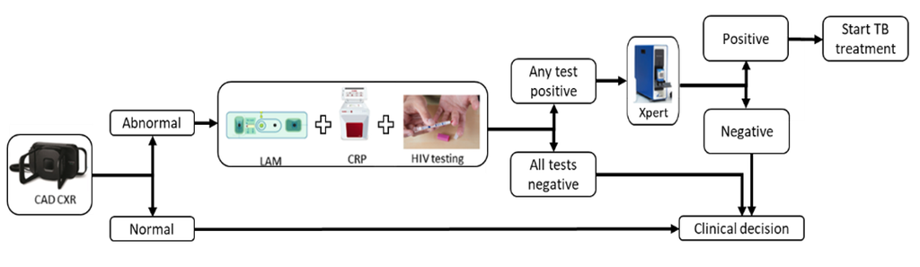

The example algorithm (adpated from the study protocol) evaluated in this SAP using simulated data to illustrate how algorithms will be evaluated.

```r
analysisFunBayesBetaParsAlgo<-function(dat,c,r,s,prior_a=1/3,prior_b=1/3){
  dat<-dat %>% dplyr::filter(country==c & region==r & setting==s)

  prevalenceTB=propEstBetaBayes(k=sum(dat$reference),n=nrow(dat),prior_a=prior_a,prior_b=prior_b)$parameters

  included<-rep(TRUE,nrow(dat))
  posRes<-included & (dat$cad==1)
  posPropCad=propEstBetaBayes(k=sum(posRes),n=sum(included),prior_a=prior_a,prior_b=prior_b)$parameters
  if(sum(posRes)>0){ppvCad=propEstBetaBayes(k=sum(dat$reference==1 & posRes),n=sum(posRes),prior_a=prior_a,prior_b=prior_b)$parameters}else{ppvCad=rep(NA,2)}
  if(sum(!posRes)>0){npvCad=propEstBetaBayes(k=sum(dat$reference==0 & !posRes),n=sum(!posRes),prior_a=prior_a,prior_b=prior_b)$parameters}else{npvCad=rep(NA,2)}

  included<-(dat$cad==1)
  posRes<-included & (dat$lamFuji==1 | dat$crpPoc==1 | dat$hiv==1)
  posPropLamCrpHiv=propEstBetaBayes(k=sum(posRes),n=sum(included),prior_a=prior_a,prior_b=prior_b)$parameters
  if(sum(posRes)>0){ppvLamCrpHiv=propEstBetaBayes(k=sum(dat$reference==1 & posRes),n=sum(posRes),prior_a=prior_a,prior_b=prior_b)$parameters}else{ppvLamCrpHiv=rep(NA,2)}
  if(sum(!posRes)>0){npvLamCrpHiv=propEstBetaBayes(k=sum(dat$reference==0 & !posRes),n=sum(!posRes),prior_a=prior_a,prior_b=prior_b)$parameters}else{npvLamCrpHiv=rep(NA,2)}

  included<-(dat$cad==1 & (dat$lamFuji==1 | dat$crpPoc==1 | dat$hiv==1))
  posRes<-included & (dat$xpert==1)
  posPropXpert=propEstBetaBayes(k=sum(posRes),n=sum(included),prior_a=prior_a,prior_b=prior_b)$parameters
  if(sum(posRes)>0){ppvXpert=propEstBetaBayes(k=sum(dat$reference==1 & posRes),n=sum(posRes),prior_a=prior_a,prior_b=prior_b)$parameters}else{ppvXpert=rep(NA,2)}
  if(sum(!posRes)>0){npvXpert=propEstBetaBayes(k=sum(dat$reference==0 & !posRes),n=sum(!posRes),prior_a=prior_a,prior_b=prior_b)$parameters}else{npvXpert=rep(NA,2)}

  included<-rep(TRUE,nrow(dat))
  posRes<-included & (dat$cad==1 & (dat$lamFuji==1 | dat$crpPoc==1 | dat$hiv==1) & dat$xpert==1)
  posPropOverall=propEstBetaBayes(k=sum(posRes),n=sum(included),prior_a=prior_a,prior_b=prior_b)$parameters
  if(sum(posRes)>0){ppvOverall=propEstBetaBayes(k=sum(dat$reference==1 & posRes),n=sum(posRes),prior_a=prior_a,prior_b=prior_b)$parameters}else{ppvOverall=rep(NA,2)}
  if(sum(!posRes)>0){npvOverall=propEstBetaBayes(k=sum(dat$reference==0 & !posRes),n=sum(!posRes),prior_a=prior_a,prior_b=prior_b)$parameters}else{npvOverall=rep(NA,2)}
  if(sum(dat$reference==1)>0){sensOverall=propEstBetaBayes(k=sum(dat$reference==1 & posRes),n=sum(dat$reference==1),prior_a=prior_a,prior_b=prior_b)$parameters}else{sensOverall=rep(NA,2)}
  if(sum(dat$reference==1)>0){specOverall=propEstBetaBayes(k=sum(dat$reference==0 & !posRes),n=sum(dat$reference==0),prior_a=prior_a,prior_b=prior_b)$parameters}else{specOverall=rep(NA,2)}

  return(c(prevalenceTB,posPropCad,ppvCad,npvCad,posPropLamCrpHiv,ppvLamCrpHiv,npvLamCrpHiv,posPropXpert,ppvXpert,npvXpert,posPropOverall,ppvOverall,npvOverall,sensOverall,specOverall))
}
```

We only report positive proportions, PPV, NPV for each stage, but also report overall TB prevalence according to the reference test, as well as positive proportion, PPV, NPV, sensitivity and specificity for the full algorithm; see Table 11.

```r
dfResPrimBayesBetaAlgo<-data.frame(
  country=c(rep("Cameroon",4),rep("Nigeria",4),rep("Kenya",2),rep("Bangladesh",3),rep("Brazil",2),rep("Vietnam",3),rep("Malawi",1)),
  region=c(rep("",4+4+2+3),"Aracaju","Maceio",rep("",3+1)),
  setting=c("PHC","District","Informal settlements ACF","Children","PHC","District","Nomads","IDP / refugees","PHC","District","PHC","District","Informal settlements ACF","PHC","PHC","PHC","Informal settlements ACF","Children","PHC"),

  prevalenceTB_a=NA,
  prevalenceTB_b=NA,

  posPropCad_a=NA,
  posPropCad_b=NA,
  ppvCad_a=NA,
  ppvCad_b=NA,
  npvCad_a=NA,
  npvCad_b=NA,

  posPropLamCrpHiv_a=NA,
  posPropLamCrpHiv_b=NA,
  ppvLamCrpHiv_a=NA,
  ppvLamCrpHiv_b=NA,
  npvLamCrpHiv_a=NA,
  npvLamCrpHiv_b=NA,

  posPropXpert_a=NA,
  posPropXpert_b=NA,
  ppvXpert_a=NA,
  ppvXpert_b=NA,
  npvXpert_a=NA,
  npvXpert_b=NA,

  posPropOverall_a=NA,
  posPropOverall_b=NA,
  ppvOverall_a=NA,
  ppvOverall_b=NA,
  npvOverall_a=NA,
  npvOverall_b=NA,
  sensOverall_a=NA,
  sensOverall_b=NA,
  specOverall_a=NA,
  specOverall_b=NA
)

for(i in 1:nrow(dfResPrimBayesBetaAlgo)){
  dfResPrimBayesBetaAlgo[i,-(1:3)]<-analysisFunBayesBetaParsAlgo(dat=dfSim,c=dfResPrimBayesBetaAlgo$country[i],r=dfResPrimBayesBetaAlgo$region[i],s=dfResPrimBayesBetaAlgo$setting[i])
}

dfResPrimBayesBetaAlgo %>%
  dplyr::select(!country) %>%
  kable(row.names=F,col.name=c("Region","Setting",rep(c("a","b"),15)),caption="Numbers in brackets indicate 95% Bayesian confidence intervals (highest posterior density intervals).",digits=2) %>%
  kable_styling(full_width=FALSE) %>%
  add_header_above(c(" "=2,"Prevalence of TB"=2,rep(c("Proportion of positive tests"=2,"PPV"=2,"NPV"=2),3),c("Proportion of positive tests"=2,"PPV"=2,"NPV"=2,"Sensitivity"=2,"Specificity"=2))) %>%
  add_header_above(c(" "=4,"CAD CXR"=6,"LAM + CRP POC + HIV | CAD CXR positive"=6,"Xpert single | LAM + CRP POC + HIV positive, CAD CXR positive"=6,"Overall"=10)) %>%
  pack_rows("Cameroon",1,4) %>%
  pack_rows("Nigeria",5,8) %>%
  pack_rows("Kenya",9,10) %>%
  pack_rows("Bangladesh",11,13) %>%
  pack_rows("Brazil",14,15) %>%
  pack_rows("Vietnam",16,18) %>%
  pack_rows("Malawi",19,19)
```

Table 11: Results for an example screening algorithm. We only report the posterior beta distribution parameters for each estimated probability parameter.

| Region | Setting | Prevalence of TB a | Prevalence of TB b | CAD CXR Proportion of positive tests a | CAD CXR Proportion of positive tests b | CAD CXR PPV a | CAD CXR PPV b | CAD CXR NPV a | CAD CXR NPV b | LAM + CRP POC + HIV \| CAD CXR positive Proportion of positive tests a | LAM + CRP POC + HIV \| CAD CXR positive Proportion of positive tests b | LAM + CRP POC + HIV \| CAD CXR positive PPV a | LAM + CRP POC + HIV \| CAD CXR positive PPV b | LAM + CRP POC + HIV \| CAD CXR positive NPV a | LAM + CRP POC + HIV \| CAD CXR positive NPV b | Xpert single \| LAM + CRP POC + HIV positive, CAD CXR positive Proportion of positive tests a | Xpert single \| LAM + CRP POC + HIV positive, CAD CXR positive Proportion of positive tests b | Xpert single \| LAM + CRP POC + HIV positive, CAD CXR positive PPV a | Xpert single \| LAM + CRP POC + HIV positive, CAD CXR positive PPV b | Xpert single \| LAM + CRP POC + HIV positive, CAD CXR positive NPV a | Xpert single \| LAM + CRP POC + HIV positive, CAD CXR positive NPV b | Overall Proportion of positive tests a | Overall Proportion of positive tests b | Overall PPV a | Overall PPV b | Overall NPV a | Overall NPV b | Overall Sensitivity a | Overall Sensitivity b | … |
| --- | --- | --- | --- | --- | --- | --- | --- | --- | --- | --- | --- | --- | --- | --- | --- | --- | --- | --- | --- | --- | --- | --- | --- | --- | --- | --- | --- | --- | --- | --- |
| **Cameroon** |  |  |  |  |  |  |  |  |  |  |  |  |  |  |  |  |  |  |  |  |  |  |  |  |  |  |  |  |  | … |
|  | PHC | 79.33 | 921.33 | 170.33 | 830.33 | 70.33 | 100.33 | 821.33 | 9.33 | 105.33 | 65.33 | 70.33 | 35.33 | 886.33 | 9.33 | 70.33 | 35.33 | 70.33 | 0.33 | 921.33 | 9.33 | 70.33 | 930.33 | 70.33 | 0.33 | 921.33 | 9.33 | 70.33 | 9.33 | … |
|  | District | 85.33 | 915.33 | 164.33 | 836.33 | 73.33 | 91.33 | 824.33 | 12.33 | 105.33 | 59.33 | 73.33 | 32.33 | 883.33 | 12.33 | 72.33 | 33.33 | 72.33 | 0.33 | 915.33 | 13.33 | 72.33 | 928.33 | 72.33 | 0.33 | 915.33 | 13.33 | 72.33 | 13.33 | … |
|  | Informal settlements ACF | 30.33 | 770.33 | 97.33 | 703.33 | 27.33 | 70.33 | 700.33 | 3.33 | 51.33 | 46.33 | 26.33 | 25.33 | 745.33 | 4.33 | 24.33 | 27.33 | 24.33 | 0.33 | 770.33 | 6.33 | 24.33 | 776.33 | 24.33 | 0.33 | 770.33 | 6.33 | 24.33 | 6.33 | … |
|  | Children | 17.33 | 483.33 | 72.33 | 428.33 | 14.33 | 58.33 | 425.33 | 3.33 | 35.33 | 37.33 | 14.33 | 21.33 | 462.33 | 3.33 | 15.33 | 20.33 | 14.33 | 1.33 | 482.33 | 3.33 | 15.33 | 485.33 | 14.33 | 1.33 | 482.33 | 3.33 | 14.33 | 3.33 | … |
| **Nigeria** |  |  |  |  |  |  |  |  |  |  |  |  |  |  |  |  |  |  |  |  |  |  |  |  |  |  |  |  |  | … |
|  | PHC | 153.33 | 547.33 | 190.33 | 510.33 | 134.33 | 56.33 | 491.33 | 19.33 | 155.33 | 35.33 | 134.33 | 21.33 | 526.33 | 19.33 | 133.33 | 22.33 | 133.33 | 0.33 | 547.33 | 20.33 | 133.33 | 567.33 | 133.33 | 0.33 | 547.33 | 20.33 | 133.33 | 20.33 | … |
|  | District | 119.33 | 581.33 | 163.33 | 537.33 | 103.33 | 60.33 | 521.33 | 16.33 | 127.33 | 36.33 | 102.33 | 25.33 | 556.33 | 17.33 | 102.33 | 25.33 | 102.33 | 0.33 | 581.33 | 17.33 | 102.33 | 598.33 | 102.33 | 0.33 | 581.33 | 17.33 | 102.33 | 17.33 | … |
|  | Nomads | 77.33 | 923.33 | 184.33 | 816.33 | 69.33 | 115.33 | 808.33 | 8.33 | 106.33 | 78.33 | 69.33 | 37.33 | 886.33 | 8.33 | 69.33 | 37.33 | 68.33 | 1.33 | 922.33 | 9.33 | 69.33 | 931.33 | 68.33 | 1.33 | 922.33 | 9.33 | 68.33 | 9.33 | … |
|  | IDP / refugees | 117.33 | 883.33 | 202.33 | 798.33 | 102.33 | 100.33 | 783.33 | 15.33 | 134.33 | 68.33 | 101.33 | 33.33 | 850.33 | 16.33 | 102.33 | 32.33 | 101.33 | 1.33 | 882.33 | 16.33 | 102.33 | 898.33 | 101.33 | 1.33 | 882.33 | 16.33 | 101.33 | 16.33 | … |
| **Kenya** |  |  |  |  |  |  |  |  |  |  |  |  |  |  |  |  |  |  |  |  |  |  |  |  |  |  |  |  |  | … |
|  | PHC | 59.33 | 641.33 | 122.33 | 578.33 | 51.33 | 71.33 | 570.33 | 8.33 | 74.33 | 48.33 | 51.33 | 23.33 | 618.33 | 8.33 | 52.33 | 22.33 | 51.33 | 1.33 | 640.33 | 8.33 | 52.33 | 648.33 | 51.33 | 1.33 | 640.33 | 8.33 | 51.33 | 8.33 | … |
|  | District | 138.33 | 562.33 | 205.33 | 495.33 | 123.33 | 82.33 | 480.33 | 15.33 | 146.33 | 59.33 | 122.33 | 24.33 | 538.33 | 16.33 | 115.33 | 31.33 | 114.33 | 1.33 | 561.33 | 24.33 | 115.33 | 585.33 | 114.33 | 1.33 | 561.33 | 24.33 | 114.33 | 24.33 | … |
| **Bangladesh** |  |  |  |  |  |  |  |  |  |  |  |  |  |  |  |  |  |  |  |  |  |  |  |  |  |  |  |  |  | … |
|  | PHC | 34.33 | 966.33 | 112.33 | 888.33 | 31.33 | 81.33 | 885.33 | 3.33 | 53.33 | 59.33 | 31.33 | 22.33 | 944.33 | 3.33 | 31.33 | 22.33 | 31.33 | 0.33 | 966.33 | 3.33 | 31.33 | 969.33 | 31.33 | 0.33 | 966.33 | 3.33 | 31.33 | 3.33 | … |
|  | District | 25.33 | 975.33 | 112.33 | 888.33 | 25.33 | 87.33 | 888.33 | 0.33 | 48.33 | 64.33 | 25.33 | 23.33 | 952.33 | 0.33 | 26.33 | 22.33 | 24.33 | 2.33 | 973.33 | 1.33 | 26.33 | 974.33 | 24.33 | 2.33 | 973.33 | 1.33 | 24.33 | 1.33 | … |
|  | Informal settlements ACF | 49.33 | 951.33 | 127.33 | 873.33 | 46.33 | 81.33 | 870.33 | 3.33 | 68.33 | 59.33 | 46.33 | 22.33 | 929.33 | 3.33 | 45.33 | 23.33 | 45.33 | 0.33 | 951.33 | 4.33 | 45.33 | 955.33 | 45.33 | 0.33 | 951.33 | 4.33 | 45.33 | 4.33 | … |
| **Brazil** |  |  |  |  |  |  |  |  |  |  |  |  |  |  |  |  |  |  |  |  |  |  |  |  |  |  |  |  |  | … |
| Aracaju | PHC | 74.33 | 426.33 | 110.33 | 390.33 | 64.33 | 46.33 | 380.33 | 10.33 | 80.33 | 30.33 | 64.33 | 16.33 | 410.33 | 10.33 | 64.33 | 16.33 | 64.33 | 0.33 | 426.33 | 10.33 | 64.33 | 436.33 | 64.33 | 0.33 | 426.33 | 10.33 | 64.33 | 10.33 | … |
| Maceio | PHC | 141.33 | 359.33 | 170.33 | 330.33 | 126.33 | 44.33 | 315.33 | 15.33 | 142.33 | 28.33 | 126.33 | 16.33 | 343.33 | 15.33 | 123.33 | 19.33 | 123.33 | 0.33 | 359.33 | 18.33 | 123.33 | 377.33 | 123.33 | 0.33 | 359.33 | 18.33 | 123.33 | 18.33 | … |
| **Vietnam** |  |  |  |  |  |  |  |  |  |  |  |  |  |  |  |  |  |  |  |  |  |  |  |  |  |  |  |  |  | … |
|  | PHC | 10.33 | 990.33 | 71.33 | 929.33 | 9.33 | 62.33 | 928.33 | 1.33 | 25.33 | 46.33 | 9.33 | 16.33 | 974.33 | 1.33 | 9.33 | 16.33 | 9.33 | 0.33 | 990.33 | 1.33 | 9.33 | 991.33 | 9.33 | 0.33 | 990.33 | 1.33 | 9.33 | 1.33 | … |
|  | Informal settlements ACF | 11.33 | 1489.33 | 124.33 | 1376.33 | 9.33 | 115.33 | 1374.33 | 2.33 | 37.33 | 87.33 | 9.33 | 28.33 | 1461.33 | 2.33 | 9.33 | 28.33 | 9.33 | 0.33 | 1489.33 | 2.33 | 9.33 | 1491.33 | 9.33 | 0.33 | 1489.33 | 2.33 | 9.33 | 2.33 | … |
|  | Children | 0.33 | 500.33 | 36.33 | 464.33 | 0.33 | 36.33 | 464.33 | 0.33 | 4.33 | 32.33 | 0.33 | 4.33 | 496.33 | 0.33 | 0.33 | 4.33 | . | . | 500.33 | 0.33 | 0.33 | 500.33 | . | . | 500.33 | 0.33 | . | . | … |
| **Malawi** |  |  |  |  |  |  |  |  |  |  |  |  |  |  |  |  |  |  |  |  |  |  |  |  |  |  |  |  |  | … |
|  | PHC | 93.33 | 1107.33 | 170.33 | 1030.33 | 82.33 | 88.33 | 1019.33 | 11.33 | 109.33 | 61.33 | 82.33 | 27.33 | 1080.33 | 11.33 | 79.33 | 30.33 | 79.33 | 0.33 | 1107.33 | 14.33 | 79.33 | 1121.33 | 79.33 | 0.33 | 1107.33 | 14.33 | 79.33 | 14.33 | … |

```r
dir.create("Output",showWarnings=FALSE)
write.csv(dfResPrimBayesBetaAlgo,row.names=F,file=paste(sep="","Output/S4A_exampleAlgorithm_betaDistributionParameterEstimates_",gsub(pattern="-",replacement="",Sys.Date()),".csv"))
```

## Secondary objectives analyses

Secondary objectives will use the results from the primary analyses. At the stage-gating the scientific advisory board will select the relevant combinations to take forward, while the health economic analysis (see separate analysis plan) will deal with the scale-up and cost-effectiveness objective.

**Jan15 discussion:** stage-gating?

# List of tables

Table 1: List of abbreviations

Table 2: Summary of study populations, countries, and procedures.

Table 4: Sample size calculation for adults.

Table 5: Sample size for each survey.

Table 6: 10 random rows from the simulated data.

Table 7: Sensitivities and specificities of the evaluated tests.

Table 8: Positive and negative predictive values for the evaluated tests.

Table 9: Proportions of positive test results for the evaluated tests.

Table 10: Posterior beta distribution parameters for the unconditional probability parameters.

Table 11: Results for an example screening algorithm. We only report the posterior beta distribution parameters for each estimated probability parameter.

## References

Buuren, Stef van, and Karin Groothuis-Oudshoorn. 2011. “**Mice** : Multivariate Imputation by Chained Equations in *R*.” *Journal of Statistical Software* 45 (3). https://doi.org/10.18637/jss.v045.i03.

Elm, Erik von, Douglas G. Altman, Matthias Egger, Stuart J. Pocock, Peter C. Gøtzsche, Jan P. Vandenbroucke, and STROBE Initiative. 2007. “The Strengthening the Reporting of Observational Studies in Epidemiology (STROBE) statement: guidelines for reporting observational studies.” *Lancet (London, England)* 370 (9596): 1453–57. https://doi.org/10.1016/S0140-6736(07)61602-X.

Kerman, Jouni. 2011. “Neutral Noninformative and Informative Conjugate Beta and Gamma Prior Distributions.” *Electronic Journal of Statistics* 5 (none). https://doi.org/10.1214/11-EJS648.